# SCIE 326 Midterm Q&A

### Study questions9

U6 · Q1Applied analysis

A scientific statement posits a logically consistent explanation for naturally occurring phenomenon. An important characteristic of the scientific statement is that it can be used to generate predictions that are testable, allowing the statement to be supported (not proven) or falsified through experimentation that produces consistent observations that are both replicable and natural (as opposed to supernatural). In other words, a scientific statement should

- provide an explanation or causal mechanism of a naturally occurring phenomenon, and

- generate predictions that are testable via observations that are replicable and natural.

Consider the following statements and discuss whether each fulfills the criteria for a scientific statement.

**a.** The universe and everything in it came into existence at 3 p.m., Eastern Daylight Time, on June 1, 2000.

**b.** Water is composed of hydrogen and chlorine.

**c.** The moon is made of green cheese.

**d.** The speed of light in a vacuum is about 300,000 kilometres per second.

**e.** Our personalities are influenced by the position of the planets at the time we were born.

astrologycausal mechanismcriteriaDerry, Gregory N.evidenceexplanationfalsifiedGosse, Philipmeasurementnaturally occurring phenomenonobservationpredictionpseudosciencereplicablescientific statementtestabletestable predictionstheory

Source Unit 6 Study Question 1 criteria; Derry ch. 14 (falsifiability); Derry ch. 12 (Omphalos)

Key idea: a statement can be *scientific* (testable, about natural phenomena) and still be *false*. Scientific status depends on testability, not on truth.

1. **Not scientific.** It offers no causal mechanism and no testable prediction. Any evidence of an older past (our memories, ancient rocks, starlight from billions of years ago) can simply be declared created as it is at 3 p.m. on June 1, 2000. This is Gosse's *Omphalos* argument: unfalsifiable, so outside science (Derry ch. 12).
2. **Scientific in form, but false.** It is a testable claim about composition: electrolysis or chemical analysis can check it, and it is falsified (water is hydrogen and oxygen, H2O). A false statement can still be a scientific statement.
3. **Scientific in form, but false.** It is testable (density, spectroscopy, the rock samples brought back from the moon) and has been falsified. It offers no real explanation, but it does make checkable predictions.
4. **Scientific, and well confirmed.** It is a precise, measurable, replicable claim about a natural phenomenon (the measured value is about 299,792 km per second) and is embedded in physical theory (Maxwell, relativity).
5. **Testable in principle, but fails as science.** It could be tested statistically (compare personality measures with birth charts), and controlled tests have not found such effects. There is also no plausible causal mechanism. As practised, astrology avoids clear predictions and is the course's example of a pseudoscience (no empirical support and no legitimate theoretical link, Discussion 5.1).

Reasoning and connections

Water containing chlorine is a wrong claim about the natural world, but an agreed chemical test could show it wrong. A created-past claim becomes untestable only when every apparently older trace is protected by the assumption that it was created ready-made. For astrology, specify a measurable prediction and a comparison that could count against it before judging scientific status.

5-point content self-check

1. Apply testability rather than popularity.
2. Discuss the created-past assumption in statement a.
3. Separate false composition claims from untestable claims in b and c.
4. Explain repeatable measurement in d.
5. Distinguish a precise testable astrological claim from an evasive one in e.

Study checklist, not an official marking scheme. Follow the exact command and mark allocation on the exam; a named list may require more items than the checklist has lines.

Exam tip For each statement, say *testable or not*, *natural or not*, *explanation or not*, then *confirmed, falsified, or untestable*.

U6 · Q2Definitions

Define each of the terms listed below.

**a.** logical positivism

**b.** relativism

**c.** realism

**d.** operationalism

**e.** reductionism

**f.** emergence

Bridgman, P. W.correspondencecultural relativismdefineDerry, Gregory N.Einstein, AlbertemergenceempiricismFeyerabend, PaulinductionKepler, Johanneslawlogical positivismMach, Ernstnatural selectionNewton, Isaacobservationoperationalismpoint of viewproblem of inductionrealismreductionismrelativismrules of correspondencetheorytheory-ladentheory-laden facts

Source Derry ch. 14; Discussions 3.2, 5.2

1. **Logical positivism** - a philosophy (Vienna, about 1930) joining empiricism with mathematical logic: only directly observable objects and events are valid scientific subject matter, and a theory is the network of logical relationships among observables. Unobservable concepts are allowed only if tied to observations by rules of correspondence (Mach even denied atoms). It was undermined by theory-laden facts and the problem of induction.
2. **Relativism** - the view that knowledge and truth are relative to a culture, framework or point of view, so there are no framework-free standards for judging claims (cultural relativism, Discussion 5.2; the postmodern view that science is one claimant among many; Feyerabend's "voodoo" remark).
3. **Realism** - the view that at least some theoretical entities (electrons, hydrogen atoms, natural selection, economic forces) actually exist in a reality independent of human thought. The course adopts this mild realism, the dominant view in science (Discussion 3.2).
4. **Operationalism** - P. W. Bridgman's view that a scientific concept should be defined purely by the operations that measure it (Einstein defining time by clock operations); concepts that cannot be defined operationally are scientifically meaningless.
5. **Reductionism** - explaining one level of phenomena or one science by a more fundamental one (Kepler's laws reduced to Newton's dynamics; thermodynamics reduced to statistical mechanics). Extreme reductionism (sociology reducible to physics) fails because terms rarely correspond exactly and the reducing science cannot predict most results of the reduced one.
6. **Emergence** - the holist view that a whole can be more than the sum of its parts: complex systems show emergent properties that cannot be predicted from analysis of their components (a living cell from its chemical reactions). Supported recently by complex-systems science.

Reasoning and connections

Knowing how temperature is measured illustrates an operational definition, while asking whether molecules really exist concerns realism. Explaining a material through its components is reductionist; asking how system-level properties arise concerns emergence. These contrasts prevent the six definitions from becoming an interchangeable list of philosophical labels.

5-point content self-check

1. Define all six requested terms separately.
2. Distinguish observability from theoretical reality.
3. Distinguish cultural relativism from ordinary uncertainty.
4. Explain operational definitions.
5. Contrast reductionism with emergence using examples.

Study checklist, not an official marking scheme. Follow the exact command and mark allocation on the exam; a named list may require more items than the checklist has lines.

Exam tip One-sentence definition plus one example or name for each. Pair reductionism with emergence as opposites.

U6 · Q3Short answer

Outline Thomas Kuhn's theory of how science evolves.

anomalyDerry, Gregory N.evidencehow science evolvesKuhn, Thomasparadigmscientific revolutiontheory

Source Derry ch. 14 §4, pp. 202-203; Discussion 3.2

Kuhn, *The Structure of Scientific Revolutions* (1962), based on historical study of how science is actually done:

1. **Paradigm.** A scientific community shares a set of assumptions (some tacit), techniques, methodologies, terminology and worldview.
2. **Normal science.** Work within the paradigm is puzzle solving: filling in details and solving puzzles the paradigm says are solvable. Validity is fairly straightforward, since everyone uses the same rules and language.
3. **Anomalies and crisis.** Unsolvable puzzles, loose ends and facts that do not fit accumulate until they become intolerable.
4. **Scientific revolution.** A new paradigm competes with the old. Comparison is hard because the two sides may speak different languages and even "see a different world" (phlogiston versus oxygen; caloric versus kinetic theory of heat).
5. **New consensus.** The community comes to agree that the new paradigm is better, using empirical criteria (fewer falsified statements) and non-empirical ones (it promises vigorous activity and progress). Holdouts become marginal ("cranks").
6. **New normal science** begins, and the cycle repeats.

Significance and controversy: it shows the key role of community consensus judgements; critics took it to mean validity is decided by majority rule or ideology, a reading Kuhn himself rejected.

Reasoning and connections

The phlogiston-oxygen contrast illustrates why a paradigm change can alter concepts as well as conclusions. Scientists must reassess what the evidence means under each framework. Kuhn's account explains the social and historical difficulty of that transition, but it does not mean every anomaly immediately produces a revolution or that evidence stops mattering.

5-point content self-check

1. Define a paradigm.
2. Explain normal-science puzzle solving.
3. Explain anomalies and crisis.
4. Explain revolution and comparison of rivals.
5. Explain new consensus and renewed normal science.

Study checklist, not an official marking scheme. Follow the exact command and mark allocation on the exam; a named list may require more items than the checklist has lines.

Exam tip Use Kuhn's own words: paradigm, normal science, puzzle solving, anomaly, crisis, revolution, paradigm shift, consensus.

U6 · Q4Essay

Write a short essay (300-500 words) discussing the way formal criteria are used by scientific communities in forming judgements.

ChandrasekharcriteriaDerry, Gregory N.Duhem, PierreEddingtonevidenceexplanationexplanatory powerfalsifiablefertilityformal criteriajudgementsKuhn, ThomaslawMendeleevmodelNewton, Isaacobservationparadigmpeer reviewpredictionprediction of unforeseen resultsQuine, W. V. O.Quine-Duhem thesisscientific communitiessimplicitytheorytheory-ladenvalues

Source Derry ch. 14 §4 (criteria for theory selection, judgment in science); ch. 11 (values in theory choice); ch. 15

Marking points

- Name the formal criteria (explanatory power, simplicity, fertility, prediction of the unforeseen; also accuracy, consistency, scope).
- They are not algorithms: they must be weighed, and can conflict.
- They are applied by individuals and communities, producing a provisional consensus.
- Nature constrains the judgement; social factors can delay it (Chandrasekhar and Eddington).

Model essay

Scientific communities do not choose theories by voting, but they do not choose them by a mechanical rule either. They use formal criteria, applied through human judgement, to reach a provisional consensus.

Derry lists four criteria for a good theory. **Explanatory power:** a theory that explains more, especially disparate phenomena, is better (Newton's laws cover planets, ice skaters and grandfather clocks). **Simplicity:** with fewer assumptions and more elegance, it is preferred over a cumbersome rival. **Fertility:** a good theory leads to new ideas, applications and connections, while vitalism was an intellectual dead end. **Prediction of unforeseen results:** Maxwell's equations predicted radio waves before anyone suspected them. Chapter 11 adds accuracy, consistency with other theories and broad scope. Interestingly, none of these criteria can be justified on purely empirical grounds, because rival theories may fit all known data equally well.

The criteria do not apply themselves. They can conflict: the simplest theory may not be the most accurate, and a fertile new idea may at first fit the data worse, as the Copernican theory did. Data are also theory-laden and never decisive on their own (the Quine-Duhem thesis). So judgement is needed, first by individuals and then by the community. Derry describes the process: initial concepts organize observations; theories are refined using non-empirical criteria; predictions with falsifiable consequences are tested; judgement resolves ambiguities; and the collective result is a consensus of the scientific community, held provisionally. Peer review and open debate are the institutions where these judgements are made.

The judgements are constrained by nature but not immune to social forces. When the young Chandrasekhar calculated that massive stars collapse, Eddington's prestige led the community to reject the idea; only new observations, over about two generations, established black holes (Derry ch. 15). Kuhn's work shows that consensus matters most during revolutions, when competing paradigms are hard to compare.

Formal criteria therefore act as shared standards that make scientific judgement rational without making it automatic. They keep the debate focused on explanation, simplicity, fertility and prediction, and over time, through repeated testing, nature has the final say.

Reasoning and connections

A theory may be simpler while a rival explains more, so merely naming the criteria cannot decide between them. Scientists must argue about their importance in the case at hand and seek further discriminating evidence. Mendeleev's predictions illustrate a criterion that becomes stronger when independently checked, linking judgement with public testing rather than arbitrary preference.

10-point content self-check

1. Name explanatory power.
2. Explain simplicity.
3. Explain fertility.
4. Explain unforeseen prediction.
5. Give examples of these criteria.
6. Explain why criteria may conflict.
7. Explain individual judgement.
8. Explain communal criticism.
9. Explain empirical constraints despite social influence.
10. Conclude that consensus is provisional.

Study checklist, not an official marking scheme. Follow the exact command and mark allocation on the exam; a named list may require more items than the checklist has lines.

Exam tip List all four criteria by name with examples, then explain that judgement and consensus are needed because the criteria conflict and data underdetermine theory.

U6 · Q5Definitions

Define the three types of knowledge labeled by the Greek terms epistemé, tekhné and gnosis.

conceptual frameworkdefineepisteméepistemologyevidencegnosisGreek termsmeaningtechnologytekhnétypes of knowledgeunderstanding

Source Discussion 6.1

1. **Epistemé** - knowledge as understanding: fitting within a conceptual framework. From *epistanai*, "to stand upon": knowledge supported by a secure and rational conceptual foundation, which one can defend by rational argument. (Root of "epistemology.") Example: the chemist's knowledge that water is hydrogen and oxygen.
2. **Tekhné** - skill or know-how: practical knowledge of arts and crafts, today craft, technical and engineering knowledge. (Root of "technique" and "technology.") Gained by practice or apprenticeship and validated by performance. Example: the glassblower making a flask; the musician playing an instrument.
3. **Gnosis** - the intuitive apprehension of truth, knowledge gained by direct insight into reality; today usually linked to spiritual truths. The course argues science should not ignore it, because intuition is the source of creativity in science and culture. Example: the mystic's knowledge of ultimate reality; a scientist's flash of insight (Kekulé).

Constraints: tekhné is checked by doing; epistemé is always relative to a framework and never absolutely certain about the world; gnosis carries complete conviction but must be checked because emotions, envy, pride and greed distort it.

Reasoning and connections

A glassblower can possess skill that a theorist lacks, while a theorist can explain properties the craft worker uses without articulating them. Intuitive recognition can contribute another kind of insight. Scientific practice can draw on all three, but its public claims still need reasons and evidence that others can assess.

5-point content self-check

1. Define episteme as rational understanding.
2. Define tekhne as practical skill.
3. Define gnosis as intuitive or experiential knowing.
4. Give a distinct example of each.
5. Explain how they can cooperate without being identical.

Study checklist, not an official marking scheme. Follow the exact command and mark allocation on the exam; a named list may require more items than the checklist has lines.

Exam tip Give the Greek word, the English meaning (understanding / skill / insight), how each is validated, and one example.

U6 · Q6Short answer

What are the coherence and correspondence theories of truth, and what are the limitations of each?

a prioriAzandecoherencecoherence theoryconceptual frameworkcorrespondencecorrespondence theorydeductionevidenceexplanationlimitationsmeasurementobservationtheories of truththeorytheory-ladenwitchcraft

Source Discussion 6.1

**Coherence theory:** a statement A is true with respect to a system of statements S if it is implied by S and consistent with all the statements of S (tied to them by logical implication). Example: in Euclidean geometry the angles of a triangle sum to two right angles; in spherical geometry the same statement is false. *Limitations:* truth is only relative to the system's axioms; a perfectly consistent system need not describe the real world; and since every deduction rests on earlier premises, we must eventually assume some starting statement true a priori (or argue in a circle).

**Correspondence theory:** a statement is true if it corresponds to the facts. *Limitations:* "the facts" are not always obvious; what counts as a fact may depend on the conceptual framework (facts are theory-laden). This risks a vicious circle in which a framework admits only facts that support it, as in the closed system of Azande witchcraft, or our universal tendency to read experience as support for our beliefs (Discussion 8.2).

**How science uses them:** a scientific theory must be internally coherent *and* correspond to observations. Because neither test gives certainty, science never claims absolute truth; at most, "to the best of our knowledge," the statements provide an accurate description of nature.

Reasoning and connections

A coherent fictional system could fail to describe nature, while an apparent observation can be misinterpreted through a favoured framework. Neither criterion alone guarantees truth. Comparing independent measurements and rival explanations makes their combination more reliable, connecting this answer with the difference between evidence and mere confirming instances.

5-point content self-check

1. Define coherence truth.
2. Explain its dependence on a system.
3. Define correspondence truth.
4. Explain theory-laden access to facts.
5. Explain why science uses both tests provisionally.

Study checklist, not an official marking scheme. Follow the exact command and mark allocation on the exam; a named list may require more items than the checklist has lines.

Exam tip Definition, example and limitation for each, then the conclusion that science needs both and cannot claim absolute truth.

U6 · Q7Essay

Write a short essay (300-500 words) discussing how suspension of judgement fits the inductive attitude as defined by Pólya (see Discussion 1.1).

evidenceexperimentexplanationGorgiashonestyinductive attitudeintellectual courageintellectual honestyJennermodelpoint of viewPólya, GeorgePyrrhoPyrrhonianskepticismSuppe, Fredericksuspension of judgementtheorywise restraint

Source Discussion 6.1 (Pyrrho, Gorgias, Suppe); Discussion 1.1 (Pólya); Discussion 4.1

Marking points

- Pyrrhonian suspension of judgement: neither believe nor doubt.
- Contrast with Gorgias's dogmatic, radical skepticism.
- Map onto Pólya's three moral qualities.
- Passion and suspended judgement together; Suppe's working scientist.

Model essay

Pólya's inductive attitude aims at "adapting our beliefs to our experience as efficiently as possible," and Discussion 6.1 identifies the attitude behind it as the suspension of judgement taught by the philosopher Pyrrho. In Pyrrhonian skepticism one neither believes nor doubts; one suspends judgement. This produces an unbiased mental attitude, the inductive attitude, best suited to perceiving whatever order appears in experience.

This kind of skepticism is very different from that of the Sophist Gorgias, who argued that nothing exists, that nothing could be known if it did, and that knowledge could not be communicated. Gorgias's skepticism is dogmatic: it confidently denies, and so it ends inquiry. Pyrrho's suspension keeps inquiry open, which is why it is essential for science while Gorgias's is useless.

Suspension of judgement fits each of Pólya's three moral qualities. **Intellectual courage**, being ready to revise any of our beliefs, requires that no belief be held beyond question; every belief is held with judgement suspended. **Intellectual honesty**, changing a belief when there is compelling reason, requires that we have not closed the case in advance, so that evidence can still move us. **Wise restraint**, not changing beliefs capriciously, shows that suspension is not drifting with every new opinion: one suspends judgement about ultimate truth while still giving each claim the weight its evidence deserves. Pólya's motto, "Do not believe anything, but question only what is worth questioning," is suspension of judgement put into practice.

Suspension of judgement does not mean indifference. Scientists are often passionate about their ideas, and that passion lets them pursue a "good question" with tenacity. Discussion 6.1 describes a "free play of ideas," intense like a chess champion's, controlled only by reason and publicly repeatable experience. Frederick Suppe adds that scientists working on a developing theory assume it is "literally false" in some respects, and use experiment to find its shortcomings rather than to prove or disprove it. Discussion 4.1 makes the same link: to control our natural fear of the unknown, we adopt a cool, detached point of view, suspending judgement, and so can admit ignorance and begin to reason.

In short, suspension of judgement is the inner posture of the inductive attitude. It keeps the mind open enough to learn from experience, honest enough to change, and steady enough not to change for bad reasons.

Reasoning and connections

Jenner neither accepted every report of protection nor rejected the possibility after encountering failures. Holding an explanation provisionally allowed him to investigate differences among cases. This illustrates suspension as an active discipline of testing and revision, rather than indecision or a refusal to reach any practical conclusion.

10-point content self-check

1. Define suspension of judgement.
2. Distinguish Pyrrho from dogmatic denial.
3. State Polya's inductive aim.
4. Explain intellectual courage.
5. Explain intellectual honesty.
6. Explain wise restraint.
7. Show how evidence governs revision.
8. Explain commitment without certainty.
9. Use a concrete course case.
10. Conclude that suspension supports continuing inquiry.

Study checklist, not an official marking scheme. Follow the exact command and mark allocation on the exam; a named list may require more items than the checklist has lines.

Exam tip Name Pyrrho and contrast him with Gorgias, then connect suspension of judgement to each of Pólya's three qualities by name.

U6 · Q8Short answer

What are the three fundamental metaphysical assumptions of science?

Gorgiasmetaphysical assumptionsmythico-magicalPyrrhonianskepticismSnow, Johnunderstanding

Source Discussion 6.1 (repeated in Discussion 7.2)

1. **Nature is ordered.**
2. **This order is comprehensible to human reason.**
3. **Our understanding of this order can be communicated without subjective bias.**

They are direct negations of Gorgias's three claims (nothing exists, nothing could be known, nothing could be communicated). They cannot be proved, since all reasoning needs initial assumptions, but they must be held with suspended judgement (Pyrrhonian skepticism) rather than as dogma. Discussion 7.2 shows them replacing the three mythico-magical assumptions in ancient Miletus.

Reasoning and connections

Snow's inquiry presupposed an intelligible pattern behind illness and treated that pattern as discoverable through comparison. Communicating the comparisons made the proposed understanding open to criticism. These assumptions enable the investigation, but its success in particular cases is not a deductive proof that human reason must comprehend every feature of nature.

5-point content self-check

1. State that nature is ordered.
2. Explain comprehensibility to reason.
3. Explain public communication without subjective privilege.
4. Contrast these with Gorgias's claims.
5. Explain provisional methodological commitment rather than proof.

Study checklist, not an official marking scheme. Follow the exact command and mark allocation on the exam; a named list may require more items than the checklist has lines.

Exam tip Learn these three sentences word for word; they reappear in Unit 7.

U6 · Q9Essay, dialogue form

Write a short essay (300-500 words) structured as a dialogue between a rationalist and an empiricist on the topic of the proper way to do science.

AristotleBacon, FranciscoherencecorrespondencedeductionDerry, Gregory N.Descartes, RenédialogueEinstein, AlbertempiricistexperimentGalileoHanson, N. R.inductionKepler, JohannesLavoisierlawmodelNewton, Isaacobjectionobservationpredictionproblem of inductionproper way to do sciencerationalistRutherfordtheorytheory-ladentheory-laden factsTycho Brahe

Source Derry ch. 14 §1 and §4; Discussion 6.1

Marking points

- Rationalist: Descartes; senses deceive; deduction from self-evident premises; mathematics; certainty.
- Empiricist: Bacon; observation and repeatable experiment; induction.
- Each attacks the other's weakness: the problem of induction; untested premises and theory-laden facts.
- They converge: science needs both (Galileo's mathematics plus experiment).

Model dialogue: **Rationalist (R):** Science must rest on reason. As Descartes showed, our senses can be fooled by illusions, so they are no secure foundation. We should begin with self-evident first principles and deduce their consequences, as mathematics does. Only deduction gives certainty.

**Empiricist (E):** But your first principles tell us nothing about the world until we look. Bacon was right: knowledge begins in experience. A claim is justified only if any properly trained person can repeat the observations it describes, which is why science insists on repeatable experiments.

**R:** Then you face the problem of induction. You see the sun rise a thousand times and conclude it always will, but no finite set of observations proves a universal law. Lavoisier's elements were "immutable" by countless observations, until Rutherford showed radioactive elements change into others. And your facts are not pure: Hanson showed that observations are theory-laden.

**E:** True, but your "self-evident" premises have failed too. Aristotle's natural circular motion seemed self-evident, and Tycho's precise observations forced Kepler to give it up. Euclid's geometry seemed certain, yet the real space of Einstein's theory is not Euclidean. Without observation, reason builds elegant castles in the air.

**R:** I grant that deduction only guarantees conclusions relative to the premises. Pure logic and mathematics are certain only because they say nothing about the world.

**E:** And I grant that observation needs concepts to interpret it, and that theories must be logically coherent. Falsification helps: we cannot prove a theory by induction, but a clear failed prediction can refute it.

**R:** So the coherence test is mine, and the correspondence test is yours.

**E:** Exactly. Galileo combined mathematics with experiment, and Newton deduced Kepler's laws, which Kepler had drawn from Tycho's observations. Theory guides what we observe; observation corrects theory.

**R:** Then the proper way to do science is neither pure reason nor pure experience, but a cycle of both, with the results held provisionally.

**E:** Agreed. Reason without experience is empty; experience without reason is blind.

Reasoning and connections

Galileo's example prevents the dialogue from ending in two disconnected speeches: mathematical reasoning generates a relation, while observations assess whether it describes actual motion. Deductive certainty about what follows from assumptions and empirical support for the assumptions are different achievements. Science needs both, without turning either into a guarantee of absolute knowledge.

10-point content self-check

1. Give the rationalist a clear position.
2. Explain deduction.
3. Explain distrust of the senses.
4. Give the empiricist a clear position.
5. Explain observation and induction.
6. Raise the problem of induction.
7. Challenge untested premises.
8. Acknowledge interpretation of observations.
9. Use a case joining mathematics and testing.
10. End with a reasoned reconciliation.

Study checklist, not an official marking scheme. Follow the exact command and mark allocation on the exam; a named list may require more items than the checklist has lines.

Exam tip Give each speaker their key name (Descartes; Bacon), their key argument and the other's best objection, and end with the synthesis.

### Objectives drill11

U6 · O1Objective

Describe the conditions a statement must meet in order to be, at least potentially, a scientific statement.

conditionsexplanationobservationPopper, Karlpredictionscientific statementtestable

It must concern natural (not supernatural) phenomena; offer a logically consistent explanation or causal mechanism; and generate testable predictions, checked by observations that are replicable, so it can be supported (never proved) or falsified (Popper). Unfalsifiable claims, such as an invisible substance filling the moon's craters or a universe created with a built-in past, are not scientific. (See Q1.)

U6 · O2Objective

Define the philosophical positions of logical positivism, operationalism, falseficationism, realism, relativism, rationalism and empiricism as they apply to science.

Bacon, FrancisBridgman, P. W.correspondencedeductiondefineDescartes, Renéempiricismfalsifiablefalsificationismlogical positivismoperationalismphilosophical positionsPopper, Karlrationalismrealismrelativismrules of correspondencetheory

See the must-know table and Q2. In brief: positivism (only observables, rules of correspondence); operationalism (concepts defined by measuring operations, Bridgman); falsificationism (theories must be falsifiable, never proved, Popper); realism (theoretical entities exist independently of us); relativism (truth relative to culture or framework); rationalism (knowledge by deduction from self-evident premises, Descartes); empiricism (knowledge from repeatable experience, Bacon).

U6 · O3Objective

Describe, briefly, the relationship between causality and chance, and that between reduction and emergence.

causalitychancedeterminismemergencefrequency interpretationHume, DavidKepler, JohannesNewton, Isaacpredictionprinciple of indifferenceprobabilityreductionreductionism

**Causality and chance:** causality is hard to make precise (multiple partial causes; logical necessity); Hume said we only know that one event always follows another. Physics-minded philosophers replace causality with **determinism** (predictability from equations). Chance does not contradict determinism: prediction needs a complete specification of the state, which we rarely have, so probability reflects what we don't (and perhaps can't) know. Probabilities are assigned by the **principle of indifference** (equal odds without reason to prefer) or the **frequency interpretation** (the observed ratio of occurrences). **Reduction and emergence:** reduction explains a higher level by a more fundamental one (thermodynamics by statistical mechanics; Kepler by Newton); emergence (holism) says complex wholes have properties not predictable from their parts (a living cell). They are opposing tendencies; few now hold radical reductionism.

U6 · O4Objective

Explain the statement, "Science is 'theory-laden.'"

constructsHanson, N. R.logical positivismobservationperceptstheorytheory-laden

Our observations are never raw: even "I see a tree" involves the mind building **constructs** from **percepts**. Scientific facts are constructs interpreted through theory ("the sun rises in the east" meant something different to Druids). N. R. Hanson coined "theory-laden" for this interpretive matrix. Consequence: we cannot simply prove theories by observation, since observations already contain theory (a circularity), which derails logical positivism, though how far this weakens empirical testing is debated.

U6 · O5Objective

Describe the basic ideas of "normal science" and "revolutionary science," and explain how these types of science are related in Thomas Kuhn's theory of how science evolves.

anomalyhow science evolvesKuhn, Thomasnormal scienceparadigmrevolutionary sciencetheory

Normal science is puzzle solving within an accepted paradigm; revolutionary science is the replacement of a paradigm once anomalies accumulate into a crisis. They alternate: normal science generates the anomalies that trigger revolutions, and each revolution founds a new period of normal science. (See Q3.)

U6 · O6Objective

State four criteria for selecting among competing theories.

competing theoriescriteriaDerry, Gregory N.explanatory powerfertilitypredictionprediction of unforeseen resultssimplicitytheory

Explanatory power, simplicity, fertility, and prediction of unforeseen results (Derry ch. 14). (See Q4.)

U6 · O7Objective

Discuss both the formal and the social aspects of scientific judgements.

aspectChandrasekharEddingtonfalsifiableformal aspectsjudgementspredictionscientific judgementssocial aspectstheory

Formal: the criteria for theory selection, logic, falsifiable predictions and empirical tests. Social: individuals and communities weigh the criteria, resolve ambiguities and form a provisional consensus; prestige and power can delay the outcome (Eddington versus Chandrasekhar), but nature constrains it in the end. (See Q4.)

U6 · O8Objective

Define the different types of knowledge associated with the terms epistemé, tekhné and gnosis, and describe some of the constraints on each.

constraintsdefineepistemégnosistekhnétypes of knowledgeunderstanding

Epistemé (understanding within a framework; relative, never absolutely certain about the world), tekhné (skill; validated by performance), gnosis (intuitive insight; convincing but easily distorted, so judgement must be suspended until checked). (See Q5.)

U6 · O9Objective

Give the truth conditions for both the coherence and correspondence theories of truth, describe how both theories are used in science, and explain why science can never claim to have discovered absolute truth.

absolute truthclaimcoherencecoherence theoryconditionscorrespondencecorrespondence theoryinductionobservationtheories of truththeorytruth conditions

Coherence: true if implied by and consistent with a system of statements. Correspondence: true if it corresponds to the facts. Science requires theories to be internally coherent and to correspond to observation. It cannot claim absolute truth because coherence is relative to assumed premises, facts depend on frameworks, induction never proves a universal claim, and every concept leaves something out (we "carve nature" one way rather than another). Absolute certainty exists only in pure logic and mathematics, and in the bare having of an experience, neither of which is scientific knowledge. (See Q6.)

U6 · O10Objective

Describe the difference between the radical skepticism of the sophist Gorgias and Pyrrhonian skepticism, and explain why the former is useless for science while the latter is essential.

differenceGorgiasinductive attitudePyrrhoPyrrhonianPyrrhonian skepticismradical skepticismskepticismsophist

Gorgias asserted that nothing exists, nothing could be known, and nothing could be communicated: a dogmatic denial that makes all truth relative and leaves only persuasion and custom, so inquiry is pointless. Pyrrho suspended judgement, neither believing nor doubting, which keeps inquiry open and gives the unbiased inductive attitude. Science needs the latter: doubt as a tool, not as a conclusion. (See Q7.)

U6 · O11Objective

State the three fundamental metaphysical assumptions of science.

metaphysical assumptionsunderstanding

Nature is ordered; this order is comprehensible to human reason; our understanding of this order can be communicated without subjective bias. (See Q8.)

### Practice multiple choice13

U6 · MC1Multiple choice

Which position holds that only directly observable objects and events are valid scientific subject matter?

1. a) Rationalism
2. b) Logical positivism
3. c) Realism
4. d) Conventionalism

logical positivismrationalismrealism

**Answer:** b - the Vienna Circle, about 1930.

U6 · MC2Multiple choice

Defining time by the operations with clocks used to measure it illustrates:

1. a) operationalism
2. b) falsificationism
3. c) holism
4. d) relativism

Bridgman, P. W.Einstein, Albertfalsificationismoperationalismrelativism

**Answer:** a - Bridgman, inspired by Einstein's redefinition of time.

U6 · MC3Multiple choice

Which is NOT one of Derry's four criteria for selecting among competing theories?

1. a) Simplicity
2. b) Fertility
3. c) Explanatory power
4. d) Popularity with the public

competing theoriescriteriaDerry, Gregory N.explanatory powerfertilitypredictionprediction of unforeseen resultssimplicitytheory

**Answer:** d - the fourth criterion is prediction of unforeseen results.

U6 · MC4Multiple choice

The term "theory-laden" was coined by:

1. a) Karl Popper
2. b) Thomas Kuhn
3. c) N. R. Hanson
4. d) W. V. O. Quine

Hanson, N. R.Kuhn, ThomasPopper, KarlQuine, W. V. O.theorytheory-laden

**Answer:** c - facts carry an interpretive matrix of theory.

U6 · MC5Multiple choice

The discovery that radioactive elements transform into other elements illustrates:

1. a) the failure of induction
2. b) operationalism
3. c) the principle of indifference
4. d) emergence

discoveryelementsemergenceinductionobservationoperationalismprinciple of indifference

**Answer:** a - the "immutability" of elements, supported by countless observations, turned out to be false.

U6 · MC6Multiple choice

The Quine-Duhem thesis claims that:

1. a) all theories are equally good
2. b) a theory cannot be falsified on purely logical grounds, because any observation can be accommodated by adjustments
3. c) theories are proved by induction
4. d) only observables are meaningful

claimDerry, Gregory N.Duhem, PierrefalsifiedinductionobservationQuine, W. V. O.Quine-Duhem thesistheory

**Answer:** b - Derry stresses that it does not mean all theories are equally good.

U6 · MC7Multiple choice

Knowledge as skill or know-how, validated by performance, is:

1. a) epistemé
2. b) tekhné
3. c) gnosis
4. d) doxa

epistemégnosistekhné

**Answer:** b - "the proof is in the pudding."

U6 · MC8Multiple choice

According to the coherence theory, a statement is true if:

1. a) it corresponds to the facts
2. b) it is implied by and consistent with a system of statements
3. c) most people believe it
4. d) it can be measured

coherencecoherence theorytheory

**Answer:** b - so the triangle-angle theorem is true in Euclidean but not spherical geometry.

U6 · MC9Multiple choice

Which is one of the three fundamental metaphysical assumptions of science?

1. a) Nature is capricious.
2. b) Everything is determined by willful powers.
3. c) Nature is ordered.
4. d) The future can be controlled by magic.

magicmetaphysical assumptionsmythico-magical

**Answer:** c - the other three are mythico-magical assumptions (Unit 7).

U6 · MC10Multiple choice

Gorgias's skepticism is useless for science because it:

1. a) suspends judgement
2. b) dogmatically denies that anything exists, can be known or communicated
3. c) relies on experiment
4. d) accepts all beliefs

beliefsexperimentGorgiasPyrrhonianskepticism

**Answer:** b - Pyrrhonian suspension of judgement, by contrast, keeps inquiry open.

U6 · MC11Multiple choice

In Kuhn's theory, "normal science" consists mainly of:

1. a) overthrowing paradigms
2. b) puzzle solving within an accepted paradigm
3. c) random observation
4. d) falsifying every theory

anomalyKuhn, Thomasnormal scienceobservationparadigmtheory

**Answer:** b - revolutions come when anomalies accumulate.

U6 · MC12Multiple choice

Stellar parallax, predicted by Copernican theory but not observed until about 1840, shows that:

1. a) falsificationism is rigorously enforced in practice
2. b) a good, fertile theory need not be abandoned because of one unconfirmed prediction
3. c) Copernicus was wrong
4. d) stars do not move

Copernicusfalsificationismparallaxpredictiontheory

**Answer:** b - the stars were simply much farther away than anyone suspected.

U6 · MC13Multiple choice

The principle of indifference assigns probabilities by:

1. a) counting observed frequencies
2. b) treating events as equally likely when there is no reason to think otherwise
3. c) asking experts
4. d) using determinism

determinismfrequency interpretationprinciple of indifferenceprobability

**Answer:** b - the frequency interpretation instead counts occurrences.

### Must-know lists7

U6 · L1Must-know list

Philosophical positions (Derry ch. 14; Discussions 3.2, 5.2, 6.1)

Bacon, FrancisBridgman, P. W.correspondencecultural relativismdeductionDerry, Gregory N.Descartes, RenéEinstein, AlbertempiricismexperimentfalsificationismFeyerabend, Paullogical positivismMach, Ernstnatural selectionobservationoperationalismphilosophical positionsPoincaré, HenriPopper, Karlpostmodernismrationalismrealismrelativismrules of correspondencetheory

| Position | Core claim | Name to know |
| --- | --- | --- |
| Empiricism | Knowledge rests on experience and observation; a claim is justified if any suitably trained person can undergo the experiences it states (the basis of repeatable experiments) | Francis Bacon |
| Rationalism | Knowledge rests on reason; a claim is justified if it can be derived from self-evident premises by strict logical deduction; the senses can be fooled | René Descartes |
| Logical positivism | Only directly observable objects and events are valid subject matter; science finds logical relations among observables; theoretical terms need rules of correspondence | Vienna Circle (about 1930); grandfather Ernst Mach |
| Operationalism | A concept is defined by the operations used to measure it; concepts that cannot be so defined are meaningless | P. W. Bridgman (Einstein's definition of time) |
| Falsificationism | A theory must make statements that can be falsified; theories are never proved, only confirmed provisionally or refuted | Karl Popper |
| Realism | At least some theoretical entities (electrons, natural selection) exist independently of human thought; the course's (mild) position | Discussion 3.2 |
| Relativism | Truth and knowledge are relative to a culture or framework; there are no framework-free standards (cultural relativism; postmodernism) | Feyerabend ("voodoo"); Discussion 5.2 |
| Conventionalism | Science uses conventions created by the mind, constrained indirectly by observation | Henri Poincaré |

U6 · L2Must-know list

Derry's four criteria for theory selection (ch. 14 §4, pp. 203-204)

criteriaDerry, Gregory N.empiricistexplanatory powerfertilityNewton, Isaacpredictionprediction of unforeseen resultssimplicitytheory

1. **Explanatory power** - explains more, including disparate phenomena (Newton: planets, ice skater, grandfather clock).
2. **Simplicity** - few assumptions, elegant.
3. **Fertility** - leads to new ideas, applications and connections (vitalism was a dead end).
4. **Prediction of unforeseen results** - Maxwell's theory predicted radio waves.

None can be justified on purely empiricist grounds, since rival theories may fit the known data equally well.

U6 · L3Must-know list

Three Greek words for knowledge (Discussion 6.1)

conceptual frameworkepistemégnosistekhnéunderstanding

1. **Epistemé** - understanding; knowledge that "stands upon" a secure, rational conceptual framework. Constraint: always relative to a framework; never absolute certainty about the world (only pure logic and mathematics give certainty).
2. **Tekhné** - skill, know-how, craft and technical knowledge. Validated by performance ("the proof is in the pudding").
3. **Gnosis** - intuitive apprehension of truth by direct insight. Constraint: carries strong conviction but is easily distorted by emotion, envy, pride and greed, so we must suspend judgement and check it.

U6 · L4Must-know list

Two theories of truth (Discussion 6.1)

a prioriAzandecoherencecoherence theorycorrespondencecorrespondence theorytheories of truththeory

|  | Coherence theory | Correspondence theory |
| --- | --- | --- |
| Truth condition | A is true relative to a system S if implied by S and consistent with all statements of S | A statement is true if it corresponds to the facts |
| Example | Angles of a triangle sum to two right angles in Euclidean geometry, but not in spherical geometry | 'Water is made of hydrogen and oxygen' matches what analysis finds |
| Limitation | Truth only relative to axioms; a consistent system may not describe the world; needs a priori starting assumptions | "The facts" are not always obvious; what counts as a fact depends on the framework; risk of a vicious circle (Azande) |

Science needs both, so it never claims absolute truth: "to the best of our knowledge," statements provide an accurate description of nature.

U6 · L5Must-know list

Gorgias's three claims (radical skepticism) (Discussion 6.1)

claimGorgiasradical skepticismskepticism

1. Nothing exists.
2. Even if something did exist, nobody could know it.
3. Even if somebody could know it, they could never communicate their knowledge.

U6 · L6Must-know list

Three fundamental metaphysical assumptions of science (Discussion 6.1)

Gorgiasmetaphysical assumptionsunderstanding

1. **Nature is ordered.**
2. **This order is comprehensible to human reason.**
3. **Our understanding of this order can be communicated without subjective bias.**

(Each is a direct negation of one of Gorgias's three claims.)

U6 · L7Must-know list

Kuhn's cycle (Derry ch. 14)

anomalycycleDerry, Gregory N.Kuhn, Thomasparadigmscientific revolution

Paradigm → normal science (puzzle solving) → accumulating anomalies → crisis → scientific revolution (competing paradigms) → consensus on a new paradigm → new normal science.

### Key terms12

U6 · T1Key term

**Epistemology**

Derry, Gregory N.epistemology

the branch of philosophy that studies knowledge (Discussion 6.1; Derry ch. 14).

U6 · T2Key term

**A priori / a posteriori**

a posterioria priori

known from reason, by definition (truths of reason) / known after the fact, from experience (truths of experience) (Discussion 6.1).

U6 · T3Key term

**Via negativa**

Descartes, Renévia negativa

the method of doubt (Descartes) (Discussion 6.1).

U6 · T4Key term

**Problem of induction**

Derry, Gregory N.inductionobservationproblem of induction

no finite set of observations can prove a universal statement, and induction cannot be justified without induction (Derry ch. 14).

U6 · T5Key term

**Percepts and constructs**

constructsDerry, Gregory N.percepts

raw perceptual information and the ordered concepts the mind builds from it (Derry ch. 14).

U6 · T6Key term

**Rules of correspondence**

constructscorrespondenceDerry, Gregory N.observationrulesrules of correspondence

rules connecting theoretical constructs to observations (Derry ch. 14).

U6 · T7Key term

**Theory-laden facts**

Hanson, N. R.observationtheorytheory-ladentheory-laden facts

observations that already contain theoretical interpretation (Hanson).

U6 · T8Key term

**Quine-Duhem thesis**

Derry, Gregory N.Duhem, PierreobservationQuine, W. V. O.Quine-Duhem thesistheory

underdetermination: a theory cannot be falsified on purely logical grounds, because any observation can be accommodated by adjustments elsewhere (Derry ch. 14).

U6 · T9Key term

**Paradigm, normal science, scientific revolution**

Derry, Gregory N.Kuhn, Thomasnormal scienceparadigmscientific revolution

Kuhn's terms (Derry ch. 14).

U6 · T10Key term

**Determinism**

Derry, Gregory N.determinism

the first event determines (predicts) the second (Derry ch. 14).

U6 · T11Key term

**Principle of indifference / frequency interpretation**

Derry, Gregory N.frequency interpretationprinciple of indifferenceprobability

two ways of assigning probabilities (Derry ch. 14).

U6 · T12Key term

**Reductionism / emergence (holism)**

emergencereductionism

see Q2.

### Who said what18

U6 · P1Who said what

**Max Born**

Born, Max

no philosophical highroad in science; we find our way through the jungle by trial and error (Discussion 6.1).

U6 · P2Who said what

**Plato**

Plato

the *Theaetetus* reaches no firm conclusion about knowledge; 'carve nature at the joints' (Discussion 6.1).

U6 · P3Who said what

**Gregory Bateson**

Bateson, Gregory

"information is the difference that makes a difference" (Discussion 6.1).

U6 · P4Who said what

**Jacob Bronowski**

Bronowski, Jacob

order "cannot be defined on any ground except its success" (Discussion 6.1).

U6 · P5Who said what

**Gorgias (483-378 BCE)**

Gorgiasskepticism

radical skepticism: nothing exists, cannot be known, cannot be communicated (Discussion 6.1).

U6 · P6Who said what

**Pyrrho (about 365-275 BCE)**

Pyrrho

suspension of judgement (Discussion 6.1).

U6 · P7Who said what

**René Descartes**

Derry, Gregory N.Descartes, Renérationalism

doubt everything; *cogito ergo sum*; champion of rationalism (Discussion 6.1; Derry ch. 14).

U6 · P8Who said what

**Francis Bacon**

Bacon, FrancisDerry, Gregory N.empiricism

patron saint of empiricism: systematic gathering of facts (Derry ch. 14).

U6 · P9Who said what

**Ernst Mach**

Derry, Gregory N.Mach, Ernst

grandfather of positivism; denied atoms (Derry ch. 14).

U6 · P10Who said what

**P. W. Bridgman**

Bridgman, P. W.Derry, Gregory N.

operational definitions (Derry ch. 14).

U6 · P11Who said what

**Henri Poincaré**

Derry, Gregory N.observationPoincaré, Henri

conventions created by the mind, constrained indirectly by observation (Derry ch. 14).

U6 · P12Who said what

**David Hume**

causalityDerry, Gregory N.Hume, David

causality is only constant succession; "a bad verbal habit" to call it more (Derry ch. 14).

U6 · P13Who said what

**Karl Popper**

Derry, Gregory N.falsificationismPopper, Karl

falsificationism (Derry ch. 14).

U6 · P14Who said what

**N. R. Hanson**

Derry, Gregory N.Hanson, N. R.theorytheory-laden

coined "theory-laden" (Derry ch. 14).

U6 · P15Who said what

**Pierre Duhem and W. V. O. Quine**

Derry, Gregory N.Duhem, PierreexperimentobservationQuine, W. V. O.Quine-Duhem thesis

the Quine-Duhem thesis: experiments test whole theoretical structures; any observation can be accommodated (Derry ch. 14).

U6 · P16Who said what

**Thomas Kuhn**

Derry, Gregory N.Kuhn, Thomasparadigm

paradigms, normal science, revolutions (Derry ch. 14).

U6 · P17Who said what

**Frederick Suppe**

Suppe, Fredericktheory

working scientists treat developing theories as literally false approximations to improve (Discussion 6.1).

U6 · P18Who said what

**Einstein**

Einstein, Alberttheory

the greatest mystery: why our minds produce theories that fit the world (Discussion 6.1).

Unit 7

## Is Science Value Free?

Science, Values, and Culture

Readings Derry ch. 11 "Science, Values, and Ethics" (pp. 145-157); Discussion 7.1 (science and value), Discussion 7.2 (the rise of Western science); Derry ch. 15 "The Postmodern Critique of Science" (pp. 207-213)

### Study questions9

U7 · Q1Essay

Write a short essay (300-500 words) discussing the relation between the Einstein quote given at the beginning of this unit and the Bronowski quote that heads Discussion 7.1.

Bronowski quoteBronowski, JacobDerry, Gregory N.Einstein quoteEinstein, Albertevidencehonestylawmeasurementmodeltechnologyvalues

Source Unit 7 Overview (Einstein); Discussion 7.1 (Bronowski); Derry ch. 11 §4

The quotations:

- **Einstein:** "[S]cience can only ascertain what is, but not what should be, and outside of its domain value judgments of all kinds remain necessary."
- **Bronowski:** "The values by which we are to survive are not rules for just and unjust conduct, but are those deeper illuminations in whose light justice and injustice, good and evil, means and ends are seen in fearful sharpness of outline."

Marking points

- Einstein separates fact (what is) from value (what should be).
- Bronowski says values are not rules but illuminations, and Discussion 7.1 argues science itself depends on and produces such values.
- They are compatible: Einstein speaks of the *content* of scientific conclusions, Bronowski of the *conduct* and *clarity* science requires and gives.
- Derry: science and values are related but not hierarchical; science gives "power but not wisdom."

Model essay

At first the two quotations seem to point in opposite directions. Einstein draws a sharp line: science tells us what is, never what should be, so value judgements must come from elsewhere. Bronowski, writing about science and human values, suggests that the values we need are not a code of rules at all but "deeper illuminations," a clarity of vision in which good and evil, means and ends, stand out sharply.

Read carefully, they are complementary. Einstein is talking about the conclusions of science. A measurement of radioactivity or a law of genetics does not tell us whether to build a bomb or screen embryos. Derry agrees: science and technology "give us power but not wisdom," and the resolution of ethical debates "must ultimately depend on a sagacity that comes from outside the realm of science."

Bronowski is talking about something Einstein's line leaves out: the values *inside* the practice of science. Discussion 7.1 argues that "[Y]ou cannot know what is true unless you behave in certain ways." A community seeking truth must be truthful, so science demands honesty, free inquiry, free speech, dissent and tolerance. Bronowski states the bridge between fact and value directly: "We OUGHT to act in such a way that what IS true can be verified to be so." Here an "ought" is required by the search for what "is."

Bronowski's "illuminations" also show how science serves values without dictating them. Science gives us accurate knowledge of consequences, of what pesticides do to wildlife or what a genetic test can reveal, and so lets us see our choices "in fearful sharpness of outline." It does not choose for us, which is Einstein's point.

So the two thinkers describe two sides of one relationship. Einstein reminds us that facts alone never settle what we should do; Bronowski reminds us that the pursuit of facts itself rests on, and teaches, a set of values, and that clear knowledge sharpens every moral judgement we make. As Derry concludes, science and values are related, but the relationship is not hierarchical; their roles are complementary.

Reasoning and connections

Evidence about the likely consequences of a policy does not by itself decide which consequences society ought to accept. Yet producing reliable evidence requires honesty and openness to criticism. Einstein's point about the limits of conclusions and Bronowski's point about the values of inquiry can therefore both hold, connecting Units 1 and 7.

10-point content self-check

1. Explain Einstein's fact-value distinction.
2. Explain Bronowski's account of values.
3. Distinguish scientific findings from scientific conduct.
4. Explain honesty.
5. Explain tolerance and criticism.
6. Explain how evidence informs choices.
7. Explain why an ethical premise is still needed.
8. Use a policy example.
9. Address the apparent contradiction.
10. Give a compatible interpretation.

Study checklist, not an official marking scheme. Follow the exact command and mark allocation on the exam; a named list may require more items than the checklist has lines.

Exam tip Quote or closely paraphrase both, state the apparent conflict, then resolve it (content versus conduct; illumination versus rules) with Derry's "power but not wisdom."

U7 · Q2List

Based on the readings from Chapter 11 and Chapter 15 of What Science Is, and Discussion 7.1, draw up a list of rules for professional conduct for scientists.

Derry, Gregory N.ethicsevidenceexperimentexplanationfraudHolton's four principles of integrityHolton, Geraldhonestyintegrityopen-mindednesspeer reviewprofessional conductrulesvaluesZiman, J. M.

Source Derry ch. 11, ch. 10 §3, ch. 15; Discussion 7.1

**Honesty and evidence**

1. Report results truthfully; never fabricate or falsify data (fraud betrays the community's trust).
2. Be extremely honest about the uncertainties in your knowledge (Derry ch. 11 §4).
3. Substantiate claims; do not ask for them to be taken on faith.
4. Change your mind when the evidence goes against you (open-mindedness); concede gracefully (Ziman).

**Openness and credit**

5. Publish and share results; keep secrecy to the minimum that military or commercial work truly requires.
6. Treat knowledge as public; accept no privileged sources; judge ideas on their merit, not on who proposed them.
7. Acknowledge all contributing sources; never steal another scientist's ideas (plagiarism).
8. Submit work to peer review, and review others' work fairly and carefully, without cronyism or deference to reputation.

**Respect and tolerance**

9. Tolerate dissent, protect free inquiry and free speech, and respect the dignity of colleagues and opponents; argue against ideas, not persons.
10. Share ideas generously and welcome criticism; avoid obsessive secrecy; practise humility.

**Ethics toward subjects and society**

11. Respect ethical limits on research: informed consent, no harmful experiments on unwilling or untreated subjects (the Tuskegee study, 1932-1972), humane treatment of animal subjects.
12. Scrutinize the broader ramifications of your work and take part in public debate as an informed citizen.
13. Avoid conflicts of interest, such as selling "expert" testimony.
14. Keep scientific results separate from value-laden or metaphorical interpretations, and do not pass off personal values as science (Derry ch. 15; ch. 11 on behaviourism and sociobiology).

**Holton's four principles of integrity**

15. Get it right at all costs; be a scientist first and a specialist second; contribute to science's role in our worldview; do your duty as a scientist and a human being.

Reasoning and connections

Hiding inconvenient results makes a claim harder to test, while unfair peer review can keep a better explanation out of discussion. These rules have an epistemic role as well as an ethical one: they preserve the conditions under which errors can be found and corrected. Merely announcing a code does not establish that scientists always follow it.

5-point content self-check

1. State rules for truthful reporting and uncertainty.
2. State rules for public scrutiny and credit.
3. State rules for criticism and tolerance.
4. State responsibilities toward subjects and society.
5. Explain why the rules support reliable knowledge.

Study checklist, not an official marking scheme. Follow the exact command and mark allocation on the exam; a named list may require more items than the checklist has lines.

Exam tip Group the rules under headings and include the five norms and Holton's four principles; they are the most likely marked items.

U7 · Q3Essay

Write a short essay (300-500 words) discussing Jacob Bronowski's statement, "[Y]ou cannot know what is true unless you behave in certain ways."

behaveBronowski, JacobevidenceexperimentexplanationfraudhonestyKelleyknow what is truemodelShah, IdriesStahelskivalues

Source Discussion 7.1

Marking points

- The prisoner's dilemma experiment (Kelley and Stahelski): competitors learned something false.
- General principle: truth is more likely found by open-minded exploration and vigorous debate.
- Social conditions: truthfulness, freedom, dissent, tolerance.
- Individual conditions: no fraud, no obsessive secrecy, humility, freedom from greed.

Model essay

Bronowski's claim sounds strange at first: surely truth is about the world, not about how we behave. But Discussion 7.1 shows that the way we interact with the world determines what we are able to learn about it.

The psychologists Kelley and Stahelski had students play the prisoner's dilemma, in which each player chooses to cooperate or compete without communicating. Players were sorted in advance into "cooperators" and "competitors." Two competitors simply competed and two cooperators cooperated; but when a cooperator met a competitor, the cooperator soon switched to competing to limit losses. As a result, competitors learned something false, that everybody is a competitor, while cooperators learned something true, that the world contains both kinds. The competitors' behaviour created the very evidence that confirmed their mistaken belief.

Science generalizes this lesson. "Truth is more likely to be found by open-minded exploration and vigorous debate than by adherence to dogma or authority." That principle constrains behaviour: you may not silence an opponent, only answer the argument, and you must be willing to change your mind if the evidence goes against you. Because science is a search carried out by a community, it succeeds only if each member is truthful. Bronowski states the resulting duty: "We OUGHT to act in such a way that what IS true can be verified to be so." From this follow the social values science needs: free inquiry, free thought, free speech and tolerance, which "have never been notable in a dogmatic society."

The same holds for the individual scientist. Fraud, falsifying data or stealing ideas, confuses appearance with reality and cuts the cheater off from the community's trust. Obsessive secrecy cuts a scientist off from the criticism that improves ideas, and fear of criticism has the same effect. Lack of humility makes learning impossible, and Idries Shah notes that greed, even for knowledge, prevents real learning. The Sufi who refused to debate a scholar who "was only interested in winning the argument" makes the point vividly.

Bronowski is therefore right. Knowing what is true is not a matter of having the right facts handed to us; it depends on honesty, openness and tolerance in how we look and how we argue. Those who behave as dogmatists, competitors or cheats end up, like the competitive players, confirming their own errors.

Reasoning and connections

The competitors' mistaken generalization arose partly because their own actions induced competitive responses. This is stronger than saying they were morally bad: their behaviour changed the evidence available to them. Similarly, a scientist who suppresses criticism can create an apparently unanimous environment that hides alternative explanations.

10-point content self-check

1. State Bronowski's claim.
2. Describe the prisoner's-dilemma comparison.
3. Explain what competitors learned.
4. Explain why their behaviour produced misleading evidence.
5. Contrast cooperators' experience.
6. Connect truthfulness to checking.
7. Connect tolerance to alternatives.
8. Connect openness to criticism.
9. Acknowledge limits of the illustration.
10. Conclude how conduct shapes access to truth.

Study checklist, not an official marking scheme. Follow the exact command and mark allocation on the exam; a named list may require more items than the checklist has lines.

Exam tip The prisoner's dilemma experiment is the course's key example; describe it accurately (who learned what) before generalizing.

U7 · Q4Essay

Write a short essay (300-500 words) discussing Darwin's statement, "[A]ll observation must be for or against some view if it is to be of any service."

anchoringanomalyAzandeBacon, FrancisBroad Street pumpDarwin, CharlesDerry, Gregory N.evidenceexperimentFawcett, Henryfor or against some viewheuristichypothesisMendeleevmodelobservationPoincaré, HenriRayleigh, LordSnow, Johntheorytheory-ladenTorricelli, EvangelistaWittgenstein, Ludwig

Source Discussion 7.2 (Darwin's 1861 letter to Henry Fawcett); Discussion 5.2; Derry chs. 2, 4, 14

Marking points

- Observation becomes evidence only relative to a hypothesis (evidence versus instance).
- This marks the transition from traditional belief to science.
- Against naive Baconian fact-gathering (Poincaré's heap of stones).
- Cautions: theory-laden observation, anchoring; observations must be able to count *against*, and surprises still matter.

Model essay

In 1861 Darwin wrote to Henry Fawcett that "all observation must be for or against some view if it is to be of any service." The statement captures the step that, according to Discussion 7.2, turned traditional belief into science.

An observation is useful when it bears on a question. Discussion 7.2 says the key move was realizing that "at least some forms of experience can be taken as evidence," able to test a belief rather than merely illustrate it. Once observations are for or against a view, beliefs become working hypotheses. Snow's observations were useful because they bore on two rival views: the Broad Street pump, the brewery workers and the water-company death rates counted for the water theory and against the effluvia theory.

The statement also rejects the naive picture of science as collecting facts first and theorizing later. Bacon imagined systematic fact-gathering, but Poincaré warned that a collection of facts is no more a science than a heap of stones is a house. Mendeleev measured atomic weights because his periodic system needed them, and Torricelli's mercury experiment was designed as a test of his view that air has weight. Without a view, we would not know what to look at; Wittgenstein's line opening Unit 8 makes the same point: tell me how you are searching, and I will tell you what you are searching for.

But the "view" must be one that the observation could go *against*. If every observation is read as support, it becomes an instance, as with the Azande oracle, rather than evidence. Discussion 8.2 warns that the anchoring heuristic tempts us to do exactly this. Derry adds that observations are theory-laden, so the view shapes what we see, which is why science needs controls, replication and rival hypotheses.

Darwin's maxim also needs one qualification: observations made for one view can serve another. Rayleigh measured nitrogen's density only to improve precision, yet the anomaly overturned an unstated view (that air contained no unknown gas) and revealed argon. Even a surprise is "for or against" some view once we notice it is surprising.

Darwin's statement, properly understood, defines the scientific use of observation: we look in order to test, and we must be ready for the result to go either way.

Reasoning and connections

Darwin's statement does not mean a researcher should collect only favourable observations. An observation becomes evidence because of its bearing on a view, including a bearing against it. Snow's use of exceptions shows the point: apparent difficulties became tests of what exposure actually mattered, rather than data to be omitted.

10-point content self-check

1. Explain what a view or hypothesis contributes.
2. Distinguish observation from evidential use.
3. Explain possible support.
4. Explain possible opposition.
5. Use Snow's comparison.
6. Reject indiscriminate fact accumulation.
7. Explain theory-laden interpretation.
8. Identify the danger of anchoring.
9. Allow unexpected observations to generate questions.
10. Conclude that testing requires genuine alternatives.

Study checklist, not an official marking scheme. Follow the exact command and mark allocation on the exam; a named list may require more items than the checklist has lines.

Exam tip Use the evidence versus instance distinction and one example where observation was aimed at a view (Snow or Torricelli).

U7 · Q5Short answer

What are the three basic mythico-magical assumptions about the world?

explanationmagicmetaphysical assumptionsmythico-magicalmythico-magical assumptions

Source Discussion 7.2

1. **Nature is capricious; the unknown is unknowable.**
2. **Everything is determined by external, willful powers.**
3. **The future can be controlled by magic.**

Under these beliefs, the important thing was to learn the will of the gods and supernatural powers and to placate them (offerings, submission) or control them (magic), through the magician, priest, soothsayer, oracle or prophet. In Miletus they were replaced, without anyone saying so, by the three metaphysical assumptions of science.

Reasoning and connections

If events are attributed to arbitrary supernatural wills, learning and influencing those wills can seem more useful than seeking a stable natural relationship. That inference explains the role of oracle, ritual or magic within the framework. The contrast with science concerns the assumptions governing explanation and testing, not a judgement that earlier people lacked intelligence.

5-point content self-check

1. State capricious nature and unknowability.
2. State external willful powers.
3. State control of the future through magic.
4. Explain why placation or ritual follows.
5. Contrast the scientific assumptions without caricaturing every traditional belief.

Study checklist, not an official marking scheme. Follow the exact command and mark allocation on the exam; a named list may require more items than the checklist has lines.

Exam tip Learn the three sentences word for word, and contrast each with its scientific counterpart.

U7 · Q6Applied examples

Find three examples of mythico-magical thinking in the world today (e.g., from news stories, television or popular belief systems).

belief systemsexamplelawmagicmythico-magicalmythico-magical thinkingnews storiespopular belief systems

Source Discussion 7.2

Link each example to one of the three assumptions. Illustrative examples (find current news versions):

1. **Horoscopes and "Mercury retrograde" blamed for bad luck** - events are determined by external powers (the planets), and the reasons are hidden (capricious, unknowable).
2. **"Manifesting" or law-of-attraction programs** - the future can be controlled by thoughts, rituals or vision boards (magic).
3. **Lucky charms and sports rituals** - wearing the same socks or performing a ritual to make the team win (controlling the future by magic).
4. **Curses and the evil eye** - misfortune caused by the willful power of another person or spirit (willful external powers).
5. **Superstitions such as Friday the 13th, and blaming natural disasters on divine punishment** - nature as capricious and driven by willful powers.

Reasoning and connections

A lucky-sock ritual illustrates control through magic only if the wearer takes the ritual to affect the game's outcome. Wearing familiar socks for comfort need not make that causal claim. The distinction demonstrates why a good answer explains the belief behind the behaviour instead of classifying an outward action without context.

5-point content self-check

1. Give at least three identifiable examples.
2. Match each to an assumption.
3. Explain the claimed supernatural influence.
4. Explain the proposed control or hidden cause.
5. Distinguish a labelled illustration from a documented contemporary source.

Study checklist, not an official marking scheme. Follow the exact command and mark allocation on the exam; a named list may require more items than the checklist has lines.

Exam tip Three examples, each naming which mythico-magical assumption it expresses.

U7 · Q7Applied examples

The physicists Alan Sokal and Jean Bricmont list four common abuses of science that are found in some areas of new age and postmodern discourse:

**a.** longwinded discussions of scientific theories with little or no understanding of the actual meaning of what is being discussed.

**b.** taking natural science concepts and using them in the humanities or social sciences with no rational or empirical justification to support the implied analogy.

**c.** using technical scientific language in a context where it is irrelevant.

**d.** using scientific sounding language to talk nonsense.

Find examples of each of these abuses in the popular press, on television or in other domains of popular culture.

abuseabuses of scienceanalogyBricmont, JeanDerry, Gregory N.ethicsevidenceexamplehumanitieslanguagelawmeaningnew agenonsensepostmodernpostmodern discoursescientific languagescientific sounding languagescientific theorysocial Darwinismsocial sciencesSokal, Alantechnical scientific languagetechnologytestabletheoryunderstanding

Source Unit 7 Q7 (Sokal and Bricmont); Discussion 4.2; Derry ch. 15

Illustrative examples (find current ones):

1. **Long-winded discussion without understanding:** books and talks on "quantum healing" or "quantum consciousness" that spend chapters on uncertainty and entanglement while misunderstanding what the physics says.
2. **Unjustified analogy:** claims that 'relativity proves all truth is relative,' or that 'the second law of thermodynamics proves society must decay,' or the old social Darwinism; a physics or biology concept is carried into ethics or society with no argument that the analogy holds.
3. **Irrelevant technical language:** cosmetics and wellness ads with "DNA repair," "molecular," "ionic" or "nano" technology; management speakers describing a company reorganization as a "quantum leap" or "chaos theory."
4. **Scientific-sounding nonsense:** products that "balance your energy field," "raise your vibrational frequency" or "restructure water molecules"; Derry's perpetual-motion inventor saying the load current creates no anti-torque so output exceeds input (Derry, p. 169).

Reasoning and connections

A metaphor such as quantum leap is not automatically an abuse. The problem arises when the metaphor is presented as scientific support for a claim about an unrelated subject without an argument or evidence. For each example, identify the precise inference being invited and why the scientific vocabulary does not justify it.

5-point content self-check

1. Cover all four Sokal-Bricmont categories.
2. Explain the misunderstood concept.
3. Explain the unsupported analogy.
4. Explain irrelevance of technical wording.
5. Explain why the final example lacks a clear testable meaning.

Study checklist, not an official marking scheme. Follow the exact command and mark allocation on the exam; a named list may require more items than the checklist has lines.

Exam tip One example for each of the four abuses, labelled a-d, with a phrase saying why it is an abuse.

U7 · Q8Summary

Try to give a simple, one-sentence summary of this paragraph by the postmodern French sociologist and philosopher Jean Baudrillard. [It is possible to do so!]

Our complex, metastatic, viral systems, condemned to the exponential dimension alone (be it that of exponential stability or instability), to eccentricity and indefinite fractal scissiparity, can no longer come to an end. Condemned to an intense metabolism, to an intense internal metastasis, they become exhausted within themselves and no longer have any destination, any end, any otherness, any fatality. They are condemned, precisely, to the epidemic, to the endless excrescences of the fractal and not to the reversibility and perfect resolution of the fateful.

Baudrillard, JeanBricmont, Jeanexplanationmeaningone-sentence summarypostmodernscientific meaningSokal, Alan

Source Unit 7 Q8; Sokal and Bricmont's abuses 3 and 4

**One-sentence summary:** *Our complex modern systems keep growing and multiplying out of control from within, without any goal or ending.*

Comment: the paragraph uses scientific words (metastatic, viral, exponential, fractal, scissiparity, meaning splitting by fission) as metaphors with no scientific meaning in context. It is an example of Sokal and Bricmont's abuses (c) and (d): technical language where it is irrelevant, and scientific-sounding language for a simple (or empty) idea.

Reasoning and connections

The one-sentence answer above is the response to the actual task. The discussion of jargon explains the paraphrase for study purposes. It should not be added to an exam response that explicitly requests only one sentence: the command in the question takes priority over any general points-per-mark practice rule.

5-point content self-check

1. Keep the requested summary to one sentence.
2. Retain uncontrolled internal growth.
3. Retain proliferation.
4. Retain lack of destination or ending.
5. Treat any later commentary as explanation outside the requested sentence.

Study checklist, not an official marking scheme. Follow the exact command and mark allocation on the exam; a named list may require more items than the checklist has lines.

Exam tip Write one plain sentence, then one line saying which abuses the paragraph shows.

U7 · Q9Essay

Write a short essay (300-500 words) discussing the apparent contradiction between the idea that all science is carried out within, and hence is influenced by, a particular cultural context, and the idea that science produces objective knowledge of the world.

Chandrasekharcoherencecontradictioncorrespondencecorrespondence theorycultural contextDerry, Gregory N.Eddingtonevidenceexperimentexplanationfactual understandingFeyerabend, PaulMendeleevmodelobjectionobjective knowledgeobservationskepticismsocial constructivismtheoryunderstandingvalues

Source Derry ch. 15; Unit 7 Overview; Discussions 5.2 and 7.2

Marking points

- State both sides: science is a cultural product; science claims objective knowledge.
- The postmodern critique (strong social constructivism, underdetermination, Feyerabend).
- Derry's replies: the continuum argument, nature's constraint (Chandrasekhar and Eddington), data plus logical coherence, theories give back more than is put in.
- Separate validity from virtue, and results from metaphorical interpretations.
- Resolution: objectivity is achieved by the social process of organized skepticism.

Model essay

Science is plainly a cultural product. Its tools (logic, mathematics, repeatable experiment) grew largely out of Greek and European culture, and Derry concedes that science "is indeed the product of a particular culture in a specific set of historical circumstances." Postmodern critics conclude that science is just one claimant among many, that its results are social constructions negotiated among scientists, and, with Feyerabend, that voodoo is no better or worse than science. Yet science claims to give objective knowledge of nature. The contradiction is only apparent.

First, culture influences *what* science studies and *how* it is described and funded, but not, in the long run, *what it finds*. Discussion 5.2 notes that cultural factors may shape research topics and presentation, yet the results still provide factual understanding of the world. Derry's example is Chandrasekhar's calculation that massive stars collapse: Eddington's prestige kept the idea down for about two generations, but new observations eventually established black holes. Social forces can delay nature's verdict; they cannot overrule it indefinitely.

Second, underdetermination is weaker than critics claim. Data alone may not fix a theory, but data working together with the demand for logical coherence "whittles down the possibilities quite dramatically," and it is hard to produce even one explanation that fits everything. Good theories also give back more than was put into them: Maxwell's equations predicted radio waves and Mendeleev's table predicted gallium. That unexpected power is hard to understand if theories were arbitrary constructions; it suggests they mirror reality in some sense.

Third, we should reject a false choice. The alternative to "science is absolutely superior" is not "all modes of thinking are equally valid"; between them lies a continuum on which judgements can be made and justified. We should also separate two questions critics often blur: whether science is *good* (a question of values) and whether it is *valid*, and separate scientific results from the value-laden metaphors people attach to them ("humanity has been dethroned").

Finally, objectivity is not freedom from culture but a product of a particular culture: the open, self-critical community described in Unit 7. Its values of public knowledge, organized skepticism, replication and tolerance of dissent are designed to cancel out individual and cultural bias. As the Unit 7 Overview puts it, science's tools evolved under selection for conclusions that satisfy both the coherence and correspondence theories of truth. Science is cultural in origin and objective in aim and method, and its objectivity is always provisional, which is exactly what makes it trustworthy.

Reasoning and connections

Chandrasekhar's conflict with Eddington illustrates how status can delay recognition without permanently determining which account fits nature. Public checking and later evidence constrain a community's preferences. Objectivity is therefore a fallible achievement of criticism and correction, rather than an absence of historical or cultural context.

10-point content self-check

1. Acknowledge cultural origins.
2. Explain cultural influence on questions.
3. Explain the strong relativist objection.
4. Distinguish influence from determination of results.
5. Explain empirical constraints.
6. Explain logical constraints.
7. Use the Chandrasekhar-Eddington case.
8. Explain organized skepticism.
9. Distinguish knowledge from ethical use.
10. Conclude with qualified objectivity.

Study checklist, not an official marking scheme. Follow the exact command and mark allocation on the exam; a named list may require more items than the checklist has lines.

Exam tip Present the postmodern argument fairly, then give at least two of Derry's replies by name (Chandrasekhar and Eddington; data plus coherence; theories give back more; the continuum).

### Objectives drill9

U7 · O1Objective

Discuss both the rules of professional conduct in science, and the more basic values that underlie these rules.

Bronowski, JacobHolton, Geraldhonestypeer reviewprofessional conductrulesvalues

Rules: the five norms (knowledge public; no privileged sources; judge ideas on merit; substantiate claims; acknowledge sources), Holton's four principles, honesty about data and uncertainty, peer review, ethical treatment of subjects. Underlying values (Bronowski): truthfulness, because science is a community search for truth ("We OUGHT to act in such a way that what IS true can be verified to be so"); independence, originality, dissent, freedom and tolerance; respect for human dignity. (See Q2, Q3.)

U7 · O2Objective

Describe the sort of activities that are considered to be misconduct in science.

fraudmisconduct

Fraud: fabricating or falsifying data; plagiarism or stealing another scientist's ideas; failing to acknowledge contributing sources; misrepresenting uncertainty or claiming more than the results show; selling biased "expert" testimony; unethical research on human or animal subjects (Tuskegee, 1932-1972). Harmful though not always misconduct: obsessive secrecy, refusing criticism. Discussion 7.1: those who commit fraud have "fallen into the illusion of identifying appearance and reality."

U7 · O3Objective

State Gerald Holton's four principles of integrity in science.

Holton's four principles of integrityHolton, Geraldintegrityprinciples of integrity

1. Try to get it right at all costs, sparing no effort.
2. Try to be a scientist first, a specialist second.
3. Try to explore and contribute to the role of science as part of our overall worldview.
4. Try to do your duty as a scientist and as a human being.

U7 · O4Objective

Describe the "first crisis of science," and state how Aristotle resolved it.

Aristotlefirst crisis of scienceGorgiaslawPlatorhetoricSocrates

The early Greek natural philosophers had no established criteria for a reliable argument, so reasoned debate risked collapsing into nonsense. The crisis came to a head with the Sophists (late 5th century BCE), who taught rhetoric to win arguments, not to find truth (in effect, truth is whatever the most persuasive speaker says), and with Gorgias's arguments against the possibility of knowledge. Socrates and Plato opposed the Sophists, but Aristotle resolved the crisis by working out the **laws of formal logic** and by the principle that conclusions are accepted only if supported by **logically sound arguments**; appeals to personality, authority or the gods were inadmissible, and analogy and metaphor could illustrate but not prove.

U7 · O5Objective

Identify some of the cultural factors that contributed to the emergence of modern science in Europe.

Aristotlecultural factorsDerry, Gregory N.discoveryemergenceemergence of modern scienceEuropeevidenceexperimentfactorshypothetico-deductivepeer reviewprobabilityPythagorasstatisticsThalestheoryvalues

Ancient roots: trade across the religiously tolerant Persian Empire exposed Miletus to many myths; Greek jury trials made reasoned argument the way to settle disputes; Thales and his rivals offered natural, criticizable theories; Pythagoras brought mathematics and experiment; Aristotle's logic. In 17th-century Europe: wealth and the spirit of exploration after the discovery of the Americas; Renaissance humanism recovering Greek texts; secular elements in European culture (Derry ch. 9); experimental testing; probability and statistics; the evidence-versus-instance distinction; the hypothetico-deductive method; and the social institutions of open communication, peer review and credit. These values reinforced the Enlightenment.

U7 · O6Objective

Describe some of the ways that science has influenced modern Western and world culture.

Darwin, CharlesdeterminismeugenicsevidenceevolutionNewton, Isaacscientismsocial DarwinismtechnologyvaluesWestern cultureworld culture

Through technology (constant change in everyday life); through worldview shifts: heliocentrism shook humanity's self-image, Darwin's evolution (misused as social Darwinism and eugenics), Newton's clockwork determinism, quantum indeterminacy invoked for free will, behaviourism and genetic determinism; through its values (openness, tolerance, evidence) feeding the Enlightenment; through scientism; and as "world science" spreading because it improves quality of life. Scientific ideas also diffuse as metaphors, often losing their precision.

U7 · O7Objective

Describe and analyse some of the postmodern claims about science.

ChandrasekharclaimcoherenceDerry, Gregory N.EddingtonevidenceFeyerabend, Paulpostmodernpostmodern claimspredictiontheory

Claims: science is a product of Western culture and just one claimant among many; its standards (evidence, logic, prediction) are cultural artifacts (Feyerabend: voodoo no better or worse); results are social constructions decided by negotiation, prestige and power (strong program); underdetermination means we invent rather than discover results; science serves political ideology and elites. Derry's analysis: extreme versions are wrong (a continuum, not two extremes; nature constrains us in the end; data plus coherence narrow theories sharply; theories give back more than is put in), but moderate versions make valuable points (social prestige can delay truth, as with Eddington and Chandrasekhar; politics shapes research agendas; gender discrimination; value-laden debates such as nature versus nurture in intelligence). (See Q9.)

U7 · O8Objective

Discuss the interrelation between science and culture.

conceptual frameworkDerry, Gregory N.interrelationscience and culturetechnologyvalue freevalues

Two-way: culture shapes which questions are asked, funding, and the conceptual frameworks used; science changes culture through technology, worldview and values. Science flourishes only in cultures that value free inquiry and tolerance; dogmatic cultures resist the values science needs. Western science became world science because it is effective. (See Unit 7 Overview, Discussions 7.1-7.2, Derry chs. 11 and 15.)

U7 · O9Objective

State four ways in which scientific language is abused.

abuseBricmont, Jeanlanguagescientific languageSokal, Alantheoryunderstanding

Sokal and Bricmont: (1) long-winded discussion of theories without understanding; (2) importing science concepts into the humanities or social sciences without justifying the analogy; (3) technical language where it is irrelevant; (4) scientific-sounding language to talk nonsense. (See Q7.)

### Practice multiple choice12

U7 · MC1Multiple choice

Which is NOT one of the common norms of scientific behaviour in Discussion 7.1?

1. a) Knowledge is public.
2. b) There are no privileged sources.
3. c) Senior scientists' claims may be taken on faith.
4. d) All contributing sources must be acknowledged.

behaviourclaim

**Answer:** c - claims are not taken on faith; they must be substantiated.

U7 · MC2Multiple choice

Gerald Holton's first principle of integrity is:

1. a) Publish as often as possible.
2. b) Try to get it right at all costs, sparing no effort.
3. c) Be a specialist first.
4. d) Never disagree with colleagues.

Holton, Geraldintegrity

**Answer:** b - and the second is to be a scientist first, a specialist second.

U7 · MC3Multiple choice

In the prisoner's dilemma experiment, who learned something false about the world?

1. a) The cooperators
2. b) The competitors
3. c) Both
4. d) Neither

experiment

**Answer:** b - competitors concluded everyone competes, because cooperators switched to competing when playing them.

U7 · MC4Multiple choice

Bronowski's ethical injunction for science is:

1. a) Knowledge is power.
2. b) We OUGHT to act in such a way that what IS true can be verified to be so.
3. c) Science is value-free.
4. d) Truth is whatever the community agrees.

Bronowski, Jacob

**Answer:** b - it links "ought" to "is."

U7 · MC5Multiple choice

Which is one of the three mythico-magical assumptions?

1. a) Nature is ordered.
2. b) The future can be controlled by magic.
3. c) Understanding can be communicated without bias.
4. d) Order is comprehensible to reason.

magicmetaphysical assumptionsmythico-magicalmythico-magical assumptionsunderstanding

**Answer:** b - the other three options are the metaphysical assumptions of science.

U7 · MC6Multiple choice

The "first crisis of science" was brought to a head by:

1. a) the Inquisition
2. b) the Sophists, who taught persuasion rather than truth
3. c) the fall of Rome
4. d) Copernicus

AristotleCopernicusfirst crisis of sciencelawsophist

**Answer:** b - Aristotle resolved it with the laws of formal logic.

U7 · MC7Multiple choice

Who is usually credited as the first scientist, for proposing that the world is made of water without reference to the gods?

1. a) Pythagoras
2. b) Thales
3. c) Empedocles
4. d) Aristotle

AristotleEmpedoclesPythagorasThales

**Answer:** b - Thales of Miletus, who also predicted the eclipse of 585 BCE.

U7 · MC8Multiple choice

Pythagoras's study of vibrating strings showed that harmonious sounds come from:

1. a) strings of equal length
2. b) lengths related by simple numerical ratios (2:1, 3:2, 4:3)
3. c) different materials
4. d) random lengths

experimentPythagoras

**Answer:** b - octave, fifth and fourth; perhaps the first conscious experiments.

U7 · MC9Multiple choice

Derry says the statement "science is value-free" is utter nonsense when it refers to:

1. a) the content of experimental results
2. b) the overall context within which science is done
3. c) mathematics
4. d) risk assessment only

Derry, Gregory N.nonsenserisk assessmentvalues

**Answer:** b - science is tied to the shared values of the scientific community.

U7 · MC10Multiple choice

The Chandrasekhar-Eddington episode shows that:

1. a) social prestige can delay acceptance of a correct idea, but nature eventually decides
2. b) science is purely a social construction
3. c) Eddington was right about black holes
4. d) calculations are never trusted

ChandrasekharEddington

**Answer:** a - black holes were accepted about two generations later.

U7 · MC11Multiple choice

Using scientific-sounding language to talk nonsense is one of the abuses identified by:

1. a) Holton
2. b) Sokal and Bricmont
3. c) Kelley and Stahelski
4. d) Hallpike

abuseBricmont, JeanHallpike, C. R.Holton, GeraldKelleylanguagenonsenseSokal, AlanStahelski

**Answer:** b - one of their four abuses of science.

U7 · MC12Multiple choice

The method of Hellenistic science after Aristotle is called:

1. a) hypothetico-deductive
2. b) speculative-deductive
3. c) inductive-experimental
4. d) operational

AristotleEuropehypothetico-deductive

**Answer:** b - experimental refutation and test design came into systematic use only in 17th-century Europe.

### Must-know lists7

U7 · L1Must-know list

Inherent values of science (Derry ch. 11 §1)

curiosityDerry, Gregory N.evidencefraudGroves, Generalhonestyopen-mindednesssimplicitytheoryvalues

1. **Free flow of information** - publish and share results; conflicts with military and industrial secrecy (Manhattan Project, General Groves).
2. **Honesty** - you cannot do science without assuming others give honest information; fraud provokes outrage.
3. **Curiosity** - learning more about nature is a positive good (not valued by everyone).
4. **Open-mindedness** - give up a belief, however strongly held, if evidence contradicts it.
5. **Values in theory choice** - accuracy, consistency, scope, simplicity, likelihood of progress.

"Science is value-free" is "utter nonsense" if it refers to the context in which science is done.

U7 · L2Must-know list

Common norms of acceptable scientific behaviour (Discussion 7.1)

behaviour

1. Knowledge is public.
2. There are no privileged sources.
3. Ideas are to be judged on their intrinsic merit, not their source.
4. Claims are not taken on faith; they must be substantiated.
5. All contributing sources must be acknowledged.

U7 · L3Must-know list

Gerald Holton's four principles of integrity in science (Discussion 7.1)

Holton's four principles of integrityHolton, Geraldintegrityprinciples of integrity

1. Try to get it right at all costs, sparing no effort.
2. Try to be a scientist first, a specialist second.
3. Try to explore and contribute to the role of science as part of our overall worldview.
4. Try to do your duty as a scientist and as a human being.

U7 · L4Must-know list

Bronowski's values that science demands (Discussion 7.1)

Bronowski, Jacobvalues

"Independence and originality, dissent and freedom and tolerance: such are the first needs of science." Free inquiry, free thought, free speech and tolerance; respect for human dignity. The ethical injunction: "We OUGHT to act in such a way that what IS true can be verified to be so."

U7 · L5Must-know list

Three mythico-magical assumptions (Discussion 7.2)

magicmetaphysical assumptionsmythico-magicalmythico-magical assumptions

1. **Nature is capricious; the unknown is unknowable.**
2. **Everything is determined by external, willful powers.**
3. **The future can be controlled by magic.**

Replaced in Miletus by the three metaphysical assumptions of science (nature is ordered; the order is comprehensible to human reason; it can be communicated without subjective bias).

U7 · L6Must-know list

The rise of Western science (Discussion 7.2)

AkhenatenAnaximanderAristotleCyrus the GreatdeductionEmpedoclesEuropeevidenceexperimentexplanationfirst crisis of scienceGorgiasHeraclitushypothetico-deductivelawpeer reviewprobabilityPythagorasreligionscientismstatisticsThalestheorytop-down

| Step | What happened |
| --- | --- |
| Traditional and early state societies | No acceptance of alternative explanations of the world (Akhenaten's religion erased after his death) |
| Persian Empire (Cyrus the Great) | Official religious tolerance; a mosaic of myths |
| Greek cities, Miletus | Jury trials; traders compare myths; disputes settled by reasoned argument |
| Thales (625-546 BCE) | First scientist: world made of water, no gods; predicted the 585 BCE eclipse; abstraction and deductive proof in geometry |
| Anaximenes, Anaximander, Heraclitus, Empedocles | Rival theories (air, the unlimited, fire, four elements), open to criticism |
| Pythagoras (582-497 BCE) | String ratios (2:1 octave, 3:2 fifth, 4:3 fourth): perhaps the first conscious experiments; laws in mathematical form |
| First crisis of science | No criteria for reliable argument; Sophists teach persuasion, not truth; Gorgias |
| Aristotle's resolution | Laws of formal logic; conclusions accepted only if supported by logically sound arguments |
| Hellenistic period | "Speculative-deductive" method: top-down deduction from metaphysical principles |
| 17th-century Europe | Wealth and exploration after the Americas; experimental testing; probability and statistics; evidence versus instance; hypothetico-deductive method; open communication, peer review, credit |
| 18th to 20th centuries | Enlightenment; then scientism; today more modest about the inner world of consciousness |

U7 · L7Must-know list

Sokal and Bricmont's four abuses of science (Unit 7 Q7)

abuseabuses of scienceBricmont, JeanSokal, Alantheoryunderstanding

1. Long-winded discussion of scientific theories with little or no understanding of what is being discussed.
2. Importing natural-science concepts into the humanities or social sciences with no rational or empirical justification for the analogy.
3. Using technical scientific language where it is irrelevant.
4. Using scientific-sounding language to talk nonsense.

### Key terms9

U7 · T1Key term

**Ethical neutrality of science**

Derry, Gregory N.ethical neutrality of scienceSnow, John

the claim that scientists only make tools; rejected by C. P. Snow and Derry (Derry ch. 11).

U7 · T2Key term

**Risk assessment**

Derry, Gregory N.risk assessmentvalues

judging dangers from sketchy data, where values can influence scientific judgements (Derry ch. 11).

U7 · T3Key term

**Social Darwinism / eugenics**

Derry, Gregory N.eugenicssocial Darwinismtheory

misuses of evolutionary theory (Derry ch. 11).

U7 · T4Key term

**Mythico-magical assumptions**

magicmythico-magicalmythico-magical assumptions

nature capricious; willful powers; magic controls the future (Discussion 7.2).

U7 · T5Key term

**First crisis of science**

first crisis of science

the lack of criteria for reliable argument, sharpened by the Sophists (Discussion 7.2).

U7 · T6Key term

**Speculative-deductive method**

deductionspeculative-deductive methodtop-down

Hellenistic top-down deduction from metaphysical principles (Discussion 7.2).

U7 · T7Key term

**Scientism**

scientism

the belief that late-19th-century science was the final step and would solve every problem (Discussion 7.2).

U7 · T8Key term

**Social constructivism (strong program)**

Derry, Gregory N.social constructivism

social forces determine scientific results (Derry ch. 15).

U7 · T9Key term

**Postmodernism**

Derry, Gregory N.postmodernismrelativism

the critique denying objectivity and definite knowledge, favouring relativism (Derry ch. 15).

### Who said what19

U7 · P1Who said what

**Albert Einstein**

Einstein, Albert

science ascertains what is, not what should be (Unit 7 Overview).

U7 · P2Who said what

**Brian Appleyard**

Appleyard, Brian

science is "spiritually corrosive" (Unit 7 Overview).

U7 · P3Who said what

**Jacob Bronowski**

Bronowski, Jacobvalues

values as "deeper illuminations"; "[Y]ou cannot know what is true unless you behave in certain ways"; the first needs of science are independence, originality, dissent, freedom and tolerance (Discussion 7.1).

U7 · P4Who said what

**Kelley and Stahelski**

experimentKelleyStahelski

prisoner's dilemma experiment on cooperators and competitors (Discussion 7.1).

U7 · P5Who said what

**J. M. Ziman**

Ziman, J. M.

advocate powerfully but concede defeat gracefully; a well-fought controversy is a form of cooperation (Discussion 7.1).

U7 · P6Who said what

**Gerald Holton**

Holton, Geraldintegrity

four principles of integrity (Discussion 7.1).

U7 · P7Who said what

**Robin Dunbar**

Dunbar, Robin

science is a long-term, patient collective project (Discussion 7.1).

U7 · P8Who said what

**Idries Shah**

Shah, Idries

greed, even for knowledge, prevents real learning (Discussion 7.1).

U7 · P9Who said what

**C. R. Hallpike**

Hallpike, C. R.

possessing science is no guarantee of wisdom (Discussion 7.2).

U7 · P10Who said what

**Charles Darwin**

Darwin, Charlesobservation

observation must be for or against some view (Discussion 7.2).

U7 · P11Who said what

**Akhenaten**

Akhenatenreligion

pharaoh whose monotheistic religion was erased: a culture that could not accept an alternative (Discussion 7.2).

U7 · P12Who said what

**Cyrus the Great**

Cyrus the Great

first official policy of religious tolerance in the Middle East (Discussion 7.2).

U7 · P13Who said what

**Thales of Miletus**

Thales

the first scientist; water as the basic substance (Discussion 7.2).

U7 · P14Who said what

**Pythagoras**

lawPythagoras

string ratios, mathematical laws (Discussion 7.2).

U7 · P15Who said what

**Aristotle**

Aristotlefirst crisis of science

resolved the first crisis of science with formal logic (Discussion 7.2).

U7 · P16Who said what

**E. A. Burtt** and **C. P. Snow**

Burtt, E. A.Derry, Gregory N.ethical neutrality of scienceSnow, Johnvalues

values hidden in presuppositions; Snow rejects the ethical neutrality of science (Derry ch. 11 epigraphs).

U7 · P17Who said what

**Alan Sokal**

Bricmont, JeanDerry, Gregory N.Sokal, Alan

1996 parody paper in a postmodern journal; with Bricmont, four abuses of science (Derry ch. 15; Unit 7 Q7).

U7 · P18Who said what

**Paul Feyerabend**

Derry, Gregory N.Feyerabend, Paul

voodoo no better or worse than science (Derry ch. 15).

U7 · P19Who said what

**Chandrasekhar and Eddington**

ChandrasekharDerry, Gregory N.Eddington

black holes resisted because of Eddington's prestige (Derry ch. 15).

Unit 8

## What Is Reason?

Reason, Heuristics, Critical Thinking, and Argument Analysis

Readings Discussion 8.1 (reason as finding a good fit), Discussion 8.2 (how rational are we?), Derry ch. 7 "Thinking Straight: Evidence, Reason, and Critical Evaluation" (pp. 89-106), Discussion 8.3 (argument analysis)

### Study questions13

U8 · Q1Short answer

List and describe the seven gestalt criteria for good form.

concisenesscriteriaDarwin, Charlesgestaltgestalt criteriaGestalt psychologistsgood formharmonyhypothesisinclusivenesslawnatural selectionNewton, IsaacOccam (William of)Occam's razorregularityseven criteriasimplicitysymmetrytheoryunderstandingunity

Source Discussion 8.1

Gestalt psychologists studied what makes a "good form" in perception; Discussion 8.1 adapts their criteria to scientific hypotheses as rules of thumb.

1. **Regularity** - a hypothesis that can be seen as an extension of existing, accepted ideas is preferred to one requiring radical changes.
2. **Symmetry** - a hypothesis symmetrically related to accepted ideas is preferred, for example an idea successful in one field carried into another by analogy.
3. **Harmony** - a hypothesis in harmony with (resonating with) accepted ideas is preferred, and so is an argument whose structure matches existing patterns of reasoning.
4. **Simplicity** - the simpler hypothesis or argument is preferred.
5. **Conciseness** - the more concise hypothesis or argument is preferred.
6. **Inclusiveness** - the hypothesis that explains the most is preferred. Remarkably, the simplest theories often turn out the most inclusive: Newton's three laws and gravitation explain planets, falling bodies and tides; Darwin's variation and natural selection explain the diversity of life.
7. **Unity** - theories that give a sense of closure, a unified understanding of a field, are the goal of science.

The first six hold only "all other things being equal," and in practice they must be traded off, so finding a good fit is more a matter of aesthetic sensitivity than of fixed rules. Simplicity and conciseness are versions of Occam's razor.

Reasoning and connections

Newton's unification of falling bodies and planetary motion illustrates inclusiveness and unity. Those virtues help explain the theory's appeal, but they cannot replace testing its consequences. Use the seven terms from Discussion 8.1, rather than substituting visual-grouping laws from another presentation of Gestalt psychology.

5-point content self-check

1. Give all seven course-specific criteria.
2. Explain each in relation to hypotheses.
3. Use a matching course example.
4. State that the preferences may conflict.
5. Distinguish attractive form from empirical confirmation.

Study checklist, not an official marking scheme. Follow the exact command and mark allocation on the exam; a named list may require more items than the checklist has lines.

Exam tip Seven names in order (Regularity, Symmetry, Harmony, Simplicity, Conciseness, Inclusiveness, Unity) with one line each; mention "all other things being equal" and Occam's razor.

U8 · Q2Applied discussion

Choose one of the two examples of the development of a scientific theory given in Chapter 2 of What Science Is, and discuss ways in which it exemplifies the idea of a good fit.

ad hoc explanationconcisenesscontinental driftDerry, Gregory N.evidenceexampleexplanationexplanatory powergestaltgood fitharmonyHess, HarryHolmes, ArthurinclusivenessMendeleevobservationplate tectonicsregularityscientific theorysimplicitysymmetrytestabletheoryunityWegener, Alfred

Source Derry ch. 2 §2, pp. 30-34; Discussion 8.1

Example: **continental drift and plate tectonics.** The story shows a poor fit becoming a good one as the pieces arrived. (The other choice is Mendeleev's periodic table; see Unit 4 Q1.)

**Why drift was at first a poor fit:**

- **Harmony and regularity failed:** continents drifting "like icebergs" clashed with common sense and established geophysics (the lower crust seemed too rigid), and Wegener's proposed force (gravity differences plus tides) was millions of times too small.
- **A rival fit existed:** sunken land bridges explained the matching fossils and rocks, so the pieces fit "in more than one way."

**How plate tectonics became a good fit:**

- **Inclusiveness:** one theory now explains the matching coastlines (using the continental shelf), the fossil and rock similarities, past climate differences, the mid-ocean ridges and rifts, the young basaltic sea floor, wandering paleomagnetic poles, the zebra-striped magnetic reversals beside the ridges, the Pacific "ring of fire," and mountain building.
- **Regularity and harmony:** the mechanism fits established physics: radioactive heating drives convection in the plastic asthenosphere (Holmes, 1928), and sea-floor spreading (Hess, about 1960) is an extension of known processes.
- **Symmetry:** magnetic stripes are mirror-symmetric on both sides of the ridges, exactly as spreading predicts.
- **Simplicity and conciseness:** a few ideas (rigid plates, convection, spreading) replace many separate ad hoc explanations such as sunken bridges.
- **Unity:** by the mid-1960s (Tuzo Wilson's synthesis) plate tectonics became "one of the fundamental organizing principles of modern geology," closing the jigsaw.

Reasoning and connections

Matching coastlines alone allow several interpretations, so they do not establish continental drift. Fossils, rock patterns, sea-floor observations and magnetic stripes strengthen the explanation because one framework accommodates several independent lines of evidence. This connects good fit with explanatory power and testable consequences, rather than a pleasing resemblance alone.

5-point content self-check

1. Name the chosen theory.
2. Explain the initial empirical pattern.
3. Apply the named good-fit criteria.
4. Explain the mechanism and independent evidence.
5. Compare the theory with rivals and acknowledge earlier difficulties.

Study checklist, not an official marking scheme. Follow the exact command and mark allocation on the exam; a named list may require more items than the checklist has lines.

Exam tip Name at least four gestalt criteria and attach a specific fact from the case to each.

U8 · Q3Short answer

What are the three heuristics that are used in making decisions? Give examples of each.

ad hoc excusesanchoringastrologyavailabilityevidenceexampleexplanationfallacyfundamental attribution errorheuristicmaking decisionsMill, John Stuartprobabilityrepresentativenesstheory

Source Discussion 8.2

1. **Representativeness** - quickly selecting a few obvious, easily recognized features of a thing and treating them as characteristic of the thing itself.

*Examples:* the percentage of women in a group is estimated higher if the women are famous; after one rude member of a group we judge the whole group rude; Mill's fallacy that great events must have great causes; the fundamental attribution error.

2. **Availability** - judging frequency, probability or causes by how easily examples come to mind (in the senses or in memory).

*Examples:* the "traffic light phenomenon" (red lights are remembered because stopping is effortful and irritating); vivid crime-scene photos sway juries; after news of a plane crash, flying feels more dangerous than driving.

3. **Anchoring** - quickly selecting an interpretation, belief, theory or scenario and holding it even against strong contrary evidence, making minor modifications or ad hoc excuses.

*Examples:* the man who says "Must be a woman driver," then "He drives just like a woman!" and "Drives like a man!"; astrology believers remembering the hits and not seeing the misses; first impressions of a person.

Reasoning and connections

The shortcuts answer different questions: representativeness judges by resemblance, availability by accessible cases, and anchoring by a retained interpretation. A vivid theft story may inflate a risk estimate through availability, while treating a first impression as a fixed explanation illustrates anchoring. Calling every mistake bias without specifying the mechanism does not explain it.

5-point content self-check

1. Define representativeness.
2. Define availability.
3. Define anchoring in the course's broad sense.
4. Give a matching example for each.
5. Explain both the practical shortcut and the possible error.

Study checklist, not an official marking scheme. Follow the exact command and mark allocation on the exam; a named list may require more items than the checklist has lines.

Exam tip Exact names, a one-line definition each, and at least one example each (the course's examples are safest).

U8 · Q4Personal examples

Give an example from your own experience of how each of these heuristics has led to a cognitive illusion.

anchoringavailabilitycognitive illusionevidenceexampleheuristicown experiencerepresentativenessstatistics

Source Discussion 8.2

Illustrative examples (replace with your own):

- **Representativeness:** I assumed a new colleague was unfriendly because he was quiet and wore headphones on his first day; I had picked a few vivid features as representative. He was simply concentrating, and turned out to be very helpful.
- **Availability:** after a friend's laptop was stolen at a coffee shop, I judged theft there to be very common and stopped working in cafés, though I knew of only one case; the vivid story was the most available memory.
- **Anchoring:** I decided early in a course that I was "bad at statistics" and treated every low quiz mark as confirmation, while explaining away my good marks as easy quizzes, until a review of all my results showed steady improvement.

For each, say what the illusion was, which heuristic produced it, and how you noticed.

Reasoning and connections

The important part of a personal example is the inferential error. One theft supports the claim that theft occurred, but not an estimate that it is common in every cafe. Comparing the vivid memory with a broader record explains how availability distorted the judgement. Use your own actual experiences rather than presenting the illustrations as biography.

5-point content self-check

1. Give a genuine personal instance for each heuristic.
2. Describe the original judgement.
3. Identify the shortcut used.
4. Explain the mismatch with better evidence.
5. Explain how you recognized or corrected it.

Study checklist, not an official marking scheme. Follow the exact command and mark allocation on the exam; a named list may require more items than the checklist has lines.

Exam tip Label each example with the heuristic and state the error it produced.

U8 · Q5Short answer

Which fallacy of causal reasoning did John Stuart Mill describe as "the most deeply-rooted, perhaps"?

causal reasoningevidencefallacyfallacy of causal reasoningheuristicMill, John Stuartreasoningrepresentativenessrepresentativeness heuristic

Source Discussion 8.2

The prejudice that "the conditions of a phenomenon must, or at least probably will, resemble the phenomenon itself": in other words, that causes resemble their effects. Examples: great events must have great causes, complex events must have complex causes, emotional events must have emotional causes (so a major historical event "must" have had a grand conspiracy behind it). It is an error produced by the **representativeness heuristic**: we look for causes whose features match the features of the effect.

Reasoning and connections

A large effect can result from a small initiating cause when a system amplifies it. Therefore the scale or emotional importance of an event does not by itself support an equally grand cause. A causal claim needs evidence about a mechanism and alternatives, not merely a match between the story and the impression made by the effect.

5-point content self-check

1. State the belief that causes resemble their effects.
2. Attribute the criticism to Mill.
3. Connect it to representativeness.
4. Give a concrete size-or-complexity example.
5. Explain why resemblance is not evidence of a cause.

Study checklist, not an official marking scheme. Follow the exact command and mark allocation on the exam; a named list may require more items than the checklist has lines.

Exam tip Give Mill's wording, one example, and link it to representativeness.

U8 · Q6Definition

What is the "fundamental attribution fallacy"?

evidenceexplanationfallacyfundamental attribution errorfundamental attribution fallacyheuristicrepresentativenessrepresentativeness heuristic

Source Discussion 8.2

The **fundamental attribution error**: when we observe other people's behaviour, we tend to assume it reflects their personality (character), not the situation in which we see them, even though we explain our own behaviour in terms of the situation. Example: another driver who cuts us off is "a jerk"; when we cut someone off, it is because we were late or did not see them. The first judgement treats one act as representative of a stable disposition while overlooking possible situational constraints. To improve the inference, examine context and behaviour across different occasions before attributing a fixed character. It is a product of the **representativeness heuristic**.

Reasoning and connections

The observed action is compatible with more than one explanation: a driver may be inconsiderate, distracted or responding to an unusual emergency. The error is treating one action as sufficient evidence of a stable character while discounting context. Comparing behaviour across situations provides a stronger basis for attribution than a first impression.

5-point content self-check

1. Define the fundamental attribution error.
2. Contrast dispositional and situational explanations.
3. Give a concrete behaviour example.
4. Connect the error to representativeness in the course.
5. Explain what evidence would improve the judgement.

Study checklist, not an official marking scheme. Follow the exact command and mark allocation on the exam; a named list may require more items than the checklist has lines.

Exam tip Name both halves: others = personality, ourselves = situation.

U8 · Q7Essay

It seems that the perception of events in terms of cause and effect is a built in aspect of the way the human mind interprets the world, to the extent that we automatically assume causal relations even in completely random sets of experiences. Write a short essay (300-500 words) discussing why such an in-built bias might be of value for a hunter-gatherer.

aspectastrologycausal modelcausal relationscause and effectevidenceexperimentexplanationhunter-gathererin-built biasmodelnatural selectionperceptionpredictionpublic policystatisticstheory

Source Discussion 8.2; Discussion 8.1 (reasoning as survival tool)

Marking points

- The bias: we infer causation from weak evidence and struggle to infer its absence (Discussion 8.2).
- Asymmetric costs: missing a real cause can be fatal; seeing a false cause is usually cheap.
- Fast learning from one or two experiences.
- Prediction and control: tools, hunting, social life.
- The cost today: superstition and astrology; science corrects it.

Model essay

Discussion 8.2 notes that we seem "genetically programmed to identify causal connections on the basis of very weak evidence," and find it very hard to infer that two things are not causally connected. For a modern scientist this is a weakness, but for a hunter-gatherer it would have been a strength.

The main reason is the difference in costs between two kinds of mistakes. Suppose a hunter hears a rustle in the grass and assumes something caused it, perhaps a predator. If he is wrong, he has wasted a few seconds running. If he assumes the rustle was random and he is wrong, he may be eaten. A mind that sees causes too readily makes many cheap mistakes and few fatal ones; a cautious, statistically correct mind would make fewer mistakes but some would be deadly. Natural selection favours the first.

A second reason is speed of learning. A hunter-gatherer cannot run controlled experiments with large samples. If someone falls ill after eating a certain berry, treating that single coincidence as a cause and avoiding the berry is a sensible rule, even if it is sometimes wrong. Learning from one or two cases kept people alive in a dangerous environment, which Discussion 8.1 describes as the reason reasoning matters: we survive "because we are able to learn from experience and make judgements."

Third, seeing the world causally gives a sense of prediction and control. Tracking animals, finding water, making tools and fire, and reading the moods of other group members all depend on linking signs to their causes. A causal story also reduces the anxiety of uncertainty, which Discussion 8.2 notes makes us hold on to explanatory frameworks.

The same bias has costs today. It produces superstitions, conspiracy theories and belief in astrology, where a few coincidental hits take on causal power and the misses go unnoticed. In a world of statistics, medicine and public policy, false causes can mislead whole societies. This is why science developed tools such as controlled experiments, random samples, statistics and the search for causal models, to keep the useful instinct while correcting its errors.

The bias is therefore an evolutionary adaptation to a world where quick, cautious causal guesses kept people alive. Science does not remove it; it disciplines it.

Reasoning and connections

The hunter-gatherer argument is an adaptive plausibility argument, not direct proof of how the bias evolved. A mistaken alarm can be less costly than ignoring a predator, so a low threshold for suspecting causes could be useful. The same threshold can create superstition, which is why controlled comparisons and attention to non-occurrences improve causal judgement.

10-point content self-check

1. Define the tendency to infer causation.
2. Frame the evolutionary argument as a plausible explanation.
3. Compare false positives and false negatives.
4. Use the predator illustration.
5. Use a food-learning illustration.
6. Explain rapid decisions under uncertainty.
7. Explain prediction and control.
8. Recognize costs of false causal beliefs.
9. Explain scientific corrective methods.
10. Conclude without claiming a demonstrated evolutionary history.

Study checklist, not an official marking scheme. Follow the exact command and mark allocation on the exam; a named list may require more items than the checklist has lines.

Exam tip The asymmetry of errors (false alarm versus missed predator) is the key argument; add one-trial learning and the modern cost.

U8 · Q8Essay

Write a short essay (300-500 words) defending the contention that the three decision heuristics are necessary for any use of language to think about or communicate experience.

anchoringavailabilitycognitive illusioncommunicate experienceconceptual frameworkdecision heuristicsheuristicHuxley, Thomas Henrylanguagemeaningmodelobservationparadigmrepresentativenessstatisticsunderstanding

Source Discussions 8.1 and 8.2; Discussion 4.2 (conceptual frameworks)

Marking points

- Representativeness = forming categories and words; we cannot keep all features in mind.
- Availability = retrieving words, meanings and comparisons quickly from memory.
- Anchoring = an interpretive framework or context, without which sentences have no meaning.
- Discussion 8.2: heuristics are essential for science; science refines them.

Model essay

Discussion 8.2 argues that the three decision heuristics, though they cause cognitive illusions, are "essential for science," because things "must be represented, placed in a context of available information for comparisons, and viewed within some conceptual framework." The same holds for any use of language.

Language depends on **representativeness**. Every word names a category, and a category picks out a few typical features while ignoring countless others. We can never keep all the features of a person, animal or object in mind, so to think "dog" or say "dog" we must let a few features stand for the whole. Discussion 8.1 describes reasoning as discriminating which things fit together into a category, which is then "reborn" as an object of consciousness that we can name and speak about. Without representativeness there would be no nouns, only an endless list of particulars.

Language depends on **availability**. To speak or understand a sentence in real time, we must retrieve words, meanings and comparisons instantly from memory. We cannot search our entire memory for every word; we use what comes to mind first. Metaphors and analogies, which much of our thinking relies on, work only because familiar images are readily available to compare with new ones.

Language depends on **anchoring**. A sentence has meaning only within a context or interpretive framework: as Discussion 4.2 notes, the cross means something different to Christians than to ancient Romans. To understand any utterance we must quickly choose an interpretation and hold it while the conversation continues; if we kept every possible interpretation open, we could never respond. Without an anchor there is no "comfortable feeling of understanding," only confusion.

The heuristics therefore make thought and communication possible, at the price of occasional errors. Science shows how to keep the benefits while reducing the costs: careful classification refines representativeness, statistics and repeatable observation correct availability, and awareness of paradigms and conceptual frameworks shows us the value and limits of our anchors. As Huxley said, scientific thought is ordinary thinking made precise; the heuristics are the ordinary thinking, and the tools of science are the precision.

Reasoning and connections

The defence concerns the broad operations described in this course: representing, retrieving and interpreting experience within a framework. It does not establish that every particular judgement bias is logically necessary for language. This qualification preserves the argument while allowing science to improve classification, memory-based comparison and willingness to revise an interpretation.

10-point content self-check

1. State why shortcuts help language.
2. Explain categories and representativeness.
3. Give a category example.
4. Explain retrieval and availability.
5. Give a retrieval example.
6. Explain context and anchoring.
7. Give an interpretation example.
8. Explain cognitive limits.
9. Acknowledge the risk of bias.
10. Defend the qualified claim that science refines these operations.

Study checklist, not an official marking scheme. Follow the exact command and mark allocation on the exam; a named list may require more items than the checklist has lines.

Exam tip Map each heuristic to one function of language (categories, retrieval, context), then end with how science refines them.

U8 · Q9Short answer

Identify the two foundations for a well-constructed scientific argument discussed in Chapter 7 of What Science Is.

argumentDerry, Gregory N.evidenceexplanationfoundationsmeasurementobservationscientific argumentSnow, John

Source Derry ch. 7, p. 89

1. **Reliable empirical evidence.**
2. **Sound logical reasoning.**

Derry: a well-constructed scientific argument "generally rests upon two foundations: reliable empirical evidence and sound logical reasoning." Arguments lacking them do not withstand the test of time; the point is not that science always has them, but that it always should.

Reliable evidence consists of observations or measurements whose methods, comparisons and possible errors can be assessed. Sound reasoning explains why those observations support the conclusion and considers relevant alternatives. In Snow's investigation, the water-company death rates supplied evidence, and comparing ingestion with effluvia supplied reasoning about transmission. Correct reasoning cannot rescue fabricated data, and accurate data cannot rescue an invalid inference.

Reasoning and connections

A logically valid inference built on fabricated measurements lacks reliable premises, while accurate observations do not justify a conclusion that does not follow from them. Snow's argument needs both credible comparisons and a reasoned link from water exposure to transmission, including consideration of rival explanations.

5-point content self-check

1. Name reliable empirical evidence.
2. Explain what makes evidence assessable.
3. Name sound logical reasoning.
4. Explain the connection between premises and conclusion.
5. Use a case to show why either foundation alone is insufficient.

Study checklist, not an official marking scheme. Follow the exact command and mark allocation on the exam; a named list may require more items than the checklist has lines.

Exam tip Use the exact phrases "reliable empirical evidence" and "sound logical reasoning."

U8 · Q10Definitions plus limitations

Define "deductive reason" and "inductive reason," and describe the limitations of each.

conditionaldeductiondeductive reasondeductive reasoningdefineDerry, Gregory N.evidenceexplanationinductioninductive reasoninductive reasoninglimitationsobservationproblem of inductionsmall samplesyllogism

Source Derry ch. 7 §1, pp. 90-92; ch. 14 (problem of induction)

**Deductive reasoning** finds relationships between statements (premises and conclusion) that **guarantee the truth of the conclusion if the premises are true**. Example (syllogism): all cats are cute; Smokey is a cat; therefore Smokey is cute. *Limitations:*

- It is only as good as its premises: a valid argument with false premises can give a false conclusion (all cows are reptiles; all reptiles can fly; so all cows can fly).
- We seldom have well-defined general premises that we know to be true.
- Its certainty is relative to the assumed premises; it adds no new information about the world beyond them.
- A true conclusion tells us nothing about the truth of the premises, and false premises tell us nothing about the conclusion.

**Inductive reasoning** uses the truth of **many particular statements to make a generalization** (every cat I have seen is cute, so all cats are cute). *Limitations:*

- Conclusions are never certain: I might meet an ugly cat tomorrow.
- The problem of induction: no finite number of observations can prove a universal statement, and justifying induction by its past success is circular (Derry ch. 14).
- Its strength depends on the number, relevance and quality of the cases: one or two examples are usually weak grounds for a broad generalization, while a large, well-controlled and relevant body of evidence can justify provisional acceptance. A single sound counterexample can nevertheless refute a universal claim.
- Inductive conclusions have turned out wrong (the "immutable" elements before radioactivity).

Reasoning and connections

A valid deduction preserves truth from its premises but does not establish those premises empirically. Induction extends beyond the observations, so even a strong pattern remains revisable. Scientists often induce a general explanation, deduce a consequence and compare that consequence with new observations. A small sample is weak for broad generalization, although one sound counterexample can defeat a universal claim.

5-point content self-check

1. Define deduction and its conditional certainty.
2. Explain dependence on premises.
3. Define induction as generalization beyond cases.
4. Explain uncertainty and sampling limitations.
5. Use contrasting examples and show how science combines the methods.

Study checklist, not an official marking scheme. Follow the exact command and mark allocation on the exam; a named list may require more items than the checklist has lines.

Exam tip One-line definition plus example for each, then two limitations each.

U8 · Q11Short answer with examples

Identify the three general categories of fallacies, and describe one fallacy from each category. Give examples of each category of fallacy from the popular press, television or other public sources.

ad hominemassuming the conversebegging the questioncategories of fallaciescategoryconverseDerry, Gregory N.evidenceexamplefallacyfalse dilemmainvalid evidenceinvalid logicinverserhetoricrhetoric and fallacyslippery slopestraw mansuppressed evidenceundistributed middle

Source Derry ch. 7 §3, pp. 98-105

Derry divides bad arguments into three categories.

1. **Invalid logic** - the argument has a logical flaw.

*Fallacy described:* **assuming the converse (affirming the consequent).** From "if A then B" and "B," concluding "A." Derry: if taxes are too high, productivity is low; productivity is low; therefore taxes are too high. (Productivity could be low for other reasons.) *Public example:* 'If a company is cutting costs, it lays off staff; this company laid off staff, so it must be in financial trouble.' (It might be reorganizing or automating.) Other invalid-logic fallacies: the inverse, the undistributed middle.

2. **Invalid evidence** - the logic may be fine but the evidence is false, partial or misleading.

*Fallacy described:* **suppressed evidence (error of omission).** We are told the truth but not the whole truth: a politician says she has only five thousand dollars in the bank and omits two million in stocks. *Public example:* an ad boasts that a cereal is "fat-free" while omitting that it is mostly sugar; a budget "increase" of 1.2% announced when inflation is 4.5%. Others: lies, quoting out of context, unreliable sources, small or non-random samples, slanted survey wording.

3. **Rhetoric and fallacy** - persuasive devices that convince without valid logic or evidence.

*Fallacy described:* **ad hominem** ("to the man"): attacking the person instead of the argument (opposing Senator Krupt's campaign-finance bill by pointing out that he used the very practices it bans). *Public example:* dismissing a climate scientist's findings because she flies to conferences; dismissing a health policy because its proposer is wealthy. Others: straw man, false dilemma ('good jobs or a livable environment'), begging the question, slippery slope ('if we ban machine guns today, they'll confiscate every gun tomorrow').

Reasoning and connections

For affirming the consequent, keep the propositions identical: if a firm is in financial trouble, it may lay off staff; it lays off staff; therefore it is in financial trouble. Other causes of layoffs defeat that inference. The example illustrates a logical defect, not an assertion that every layoff is harmless. Use actual identifiable media sources if the exam asks for collected public examples.

5-point content self-check

1. Name all three general categories.
2. Describe an invalid-logic fallacy and its structure.
3. Describe an invalid-evidence fallacy.
4. Describe a rhetorical fallacy.
5. Give a matching public example for each and explain the defect.

Study checklist, not an official marking scheme. Follow the exact command and mark allocation on the exam; a named list may require more items than the checklist has lines.

Exam tip Name the three categories exactly (invalid logic, invalid evidence, rhetoric and fallacy), then one named fallacy each with Derry's example and a public example.

U8 · Q12Argument analysis with diagrams

In Discussion 8.3, we analysed and diagrammed an argument in favour of giving creationism equal time with evolution in the public schools. Carry out a similar analysis of the argument against this idea, and construct a diagram based on your analysis. Then, combine the pro and con diagrams into a single diagram, and from this diagram list two additional directions in which each side in the debate might continue to develop their arguments.

argumentcreationismDerry, Gregory N.diagramequal timeevidenceevolutionhidden assumptionshypothesisnatural selectionobjectionpredictionpseudosciencepublic schoolsskepticismtestabletheory

Source Discussion 8.3; Derry ch. 12 §4 (creation science)

**Analysis of the con argument** (from the "Con" paragraph in Discussion 8.3):

- *Conclusion:* creationism should not be taught as a legitimate scientific alternative to evolution, so it should not get equal time.
- *Basic assumptions:* (1) science classes should teach what qualifies as science; (2) a scientific theory must be testable and must fit the evidence.
- *Hidden assumption:* not every claimed alternative deserves equal time (no one gives a flat earth equal time with a round one).
- *Evidence:* almost all biologists accept evolution; the fossil record; antibiotic-resistant bacteria; disputes among biologists concern details only, as in every accepted theory.
- *Supporting claims:* evolution is well supported; creationism rests on an untestable hypothesis and ignores or misinterprets evidence; it is "nothing more than an attempt to sneak a religious belief into science classes."

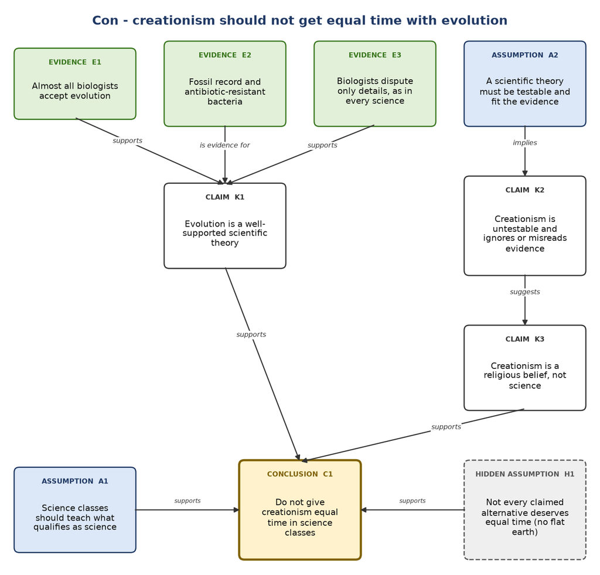

Box key: blue = assumption, dashed grey = hidden assumption, green = evidence, white = claim, red = objection, orange = counter, yellow = conclusion. Dashed red arrows oppose.

**Combined pro and con diagram.** The pro side (Discussion 8.3) assumes that any activity searching for evidence and criticizing rivals is science, that scientific theories must make exact predictions, and (hidden) that all theories deserve equal time; it cites disputes among biologists and fossil gaps. Each con point opposes one pro element.

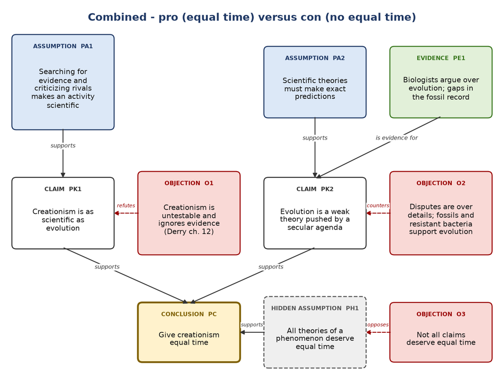

Box key: blue = assumption, dashed grey = hidden assumption, green = evidence, white = claim, red = objection, orange = counter, yellow = conclusion. Dashed red arrows oppose.

**Two further directions for each side:**

- *Pro side:* (1) produce positive, testable predictions from creationism instead of attacks on evolution, which Derry says creation science has never attempted; (2) show that biologists' disputes concern the core of evolution and not only details (for example, document that mechanisms such as natural selection are themselves in doubt).
- *Con side:* (1) show that evolution *does* make testable predictions (the order of fossils in rock strata, transitional forms, the spread of drug resistance), answering the "no exact predictions" assumption; (2) apply Derry's five criteria of pseudoscience to show creation science is static, lacks organized skepticism and disregards established results (radioactive dating, cosmology, geology), and argue that equal time is owed only to *scientific* alternatives.

Reasoning and connections

The additional pro directions are research burdens for an advocate, not evidence that the advocate has met them. Likewise, scientific consensus supports an assessment but should be connected to fossils, observed change and testable consequences. A strong diagram makes the inferential links visible and shows exactly which assumption an objection attacks.

10-point content self-check

1. State the con conclusion.
2. Identify basic assumptions.
3. Identify hidden assumptions.
4. Separate empirical evidence from authority.
5. Explain support arrows in the con map.
6. Combine support and opposition in one map.
7. Give two further pro directions.
8. Give two further con directions.
9. Distinguish proposed arguments from established facts.
10. Evaluate testability and relevance.

Study checklist, not an official marking scheme. Follow the exact command and mark allocation on the exam; a named list may require more items than the checklist has lines.

Exam tip Label every box by role (assumption, hidden assumption, evidence, claim, conclusion) and every arrow (supports, refutes). Two directions for *each* side are required.

U8 · Q13Argument diagram

In Unit 3, you read about the way that John Snow came to his conclusion about how cholera was spread. Review this story, and then construct a diagram of Snow's argument. Clearly identify his basic assumptions, evidence, responses to alternate theories and final conclusions.

alternate theoriesargumentbasic assumptionsBroad Street pumpcholeraconclusionsdiagramevidenceexperimentexplanationhidden assumptionsobjectionobservationprobabilitysmallpoxSnow's argumentSnow, Johntheorytwo water companies

Source Discussion 3.4; Discussion 8.3

**Basic assumptions:** cholera is caused by a transmissible "morbid material" that enters by being swallowed (ingestion); such an agent can be real even if it cannot yet be seen. **Hidden assumption:** the households supplied by the two water companies differ only in their water. **Evidence:** person-to-person cases; attendants who washed linens or ate in the sickroom fell ill while hand-washers rarely did; the Broad Street pump cluster and the drop after the handle was removed; the workhouse and brewery exceptions; 315 versus 37 deaths per 10,000 houses. **Responses to alternative theories:** against effluvia (not all who breathe them fall ill; outbreaks where no one was exposed; other known routes of spread exist); against 'no agent can be seen' (smallpox and chancre matter are also known only by their effects). **Conclusion:** cholera spreads through water (and hands or food) contaminated with victims' excretions, so clean water, hand washing, drainage and the other public health measures follow.

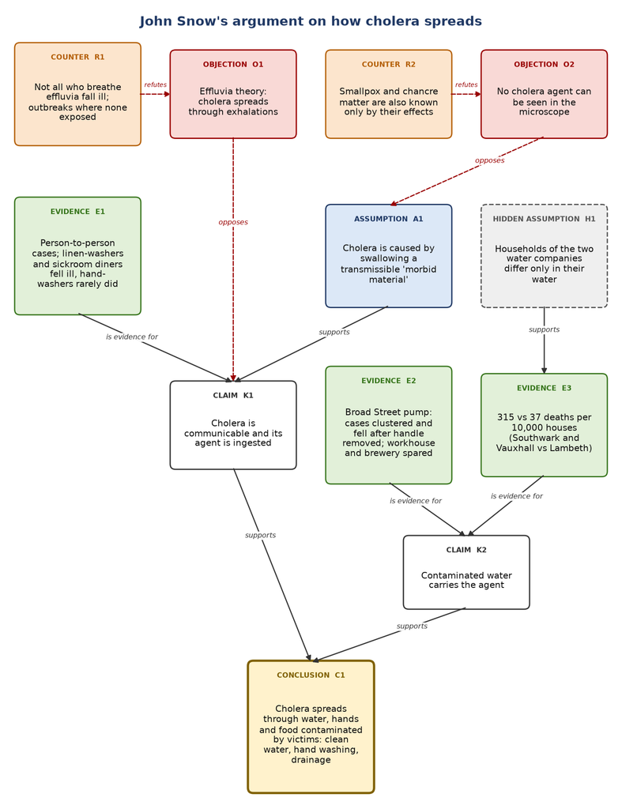

Box key: blue = assumption, dashed grey = hidden assumption, green = evidence, white = claim, red = objection, orange = counter, yellow = conclusion. Dashed red arrows oppose.

Reasoning and connections

Treat comparability of the water-company households as an assumption to examine, not an established identity between groups. The 315 versus 37 figures are deaths per 10,000 houses, not individual infection probabilities. Independent observations strengthen the water explanation, but the pump-handle episode alone is insufficient and the comparison was not a randomized experiment.

10-point content self-check

1. State basic and hidden assumptions.
2. Identify the observational evidence.
3. Explain the water-company comparison.
4. Represent the effluvia alternative.
5. Show Snow's response to it.
6. Address the unseen-agent objection.
7. Use labelled inferential arrows.
8. State the transmission conclusion.
9. State the prevention implications.
10. Identify limits of the natural comparison.

Study checklist, not an official marking scheme. Follow the exact command and mark allocation on the exam; a named list may require more items than the checklist has lines.

Exam tip Make sure the four required parts are visibly labelled: assumptions, evidence, responses to alternative theories, conclusion. The water-company figures are the strongest evidence box.

### Objectives drill12

U8 · O1Objective

Explain reasoning as a process of mentally fitting things together, and describe, briefly, three sorts of reason - empathetical, analogical and analytical.

analogicalanalogical reasonanalyticalanalytical reasonempatheticalempathetical reasonfitting things togetherpoint of viewreasoning

"Reason" comes from the root *ar*, "to fit together": sensations are fitted into perceptions, perceptions into thoughts, thoughts into judgements and actions. It needs both distinguishing parts and fitting them together (the watch). **Empathetical** reason places us experientially in another point of view and gives the felt sense of a fit; **analogical** reason fits things by likeness and metaphor; **analytical** reason distinguishes components and calculates their logical relations.

U8 · O2Objective

Describe seven criteria for a "good fit," and apply them to reasoning.

concisenesscriteriagestaltgood fitharmonyinclusivenessreasoningregularityseven criteriasimplicitysymmetryunity

Regularity, symmetry, harmony, simplicity, conciseness, inclusiveness, unity (gestalt criteria), applied "all other things being equal" with trade-offs. (See Q1, Q2.)

U8 · O3Objective

Define the three decision heuristics, and give examples of how they operate in thought.

anchoringavailabilitydecision heuristicsdefineevidenceexampleheuristicrepresentativeness

Representativeness (a few vivid features stand for the whole), availability (judging by what comes easily to mind), anchoring (holding a first interpretation against evidence). (See Q3.)

U8 · O4Objective

Give examples of some of the cognitive illusions that result from use of the three decision heuristics.

anchoringastrologyavailabilitycognitive illusiondecision heuristicsexamplefallacyfundamental attribution errorheuristicMill, John Stuartrepresentativeness

Famous women inflate estimates; one rude person stands for a group; Mill's resemblance fallacy; the fundamental attribution error (representativeness). The traffic light phenomenon; vivid crimes; plane crashes (availability). The "woman driver" joke; believing first and doubting later; astrology's remembered hits; causes seen in random covariation (anchoring). (See Q3-Q6.)

U8 · O5Objective

State the two foundations of a well-constructed scientific argument.

argumentDerry, Gregory N.evidencefoundationsscientific argument

Reliable empirical evidence and sound logical reasoning (Derry, p. 89). (See Q9.)

U8 · O6Objective

Define "deductive reasoning" and "inductive reasoning," and describe each briefly.

deductiondeductive reasoningdefineinductioninductive reasoningreasoningsyllogism

Deduction: premises guarantee the conclusion if true (syllogism). Induction: generalizing from many particular cases; never certain. (See Q10.)

U8 · O7Objective

Describe some ways in which the use of critical analysis in everyday life can benefit from scientific input.

causalitycritical analysiseveryday lifehidden assumptionsmodelmodels and analogiesnecessary and sufficientpost hocprobabilistic thinkingprobabilityquantitative thinkingscientific input

1. **Basic knowledge as constraints** - conservation of energy, the earth's finiteness and the arithmetic of exponential growth rule out some premises outright.
2. **Probabilistic thinking** - rank ideas by their probability of being right instead of taking sides; stay flexible but able to judge.
3. **Hidden assumptions** - bring unstated premises into the open.
4. **Evaluating causality** - avoid post hoc reasoning; consider common causes, feedback and coincidence; ask whether the cause is necessary and sufficient.
5. **Models and analogies** - judge an analogy as you would a model.
6. **Quantitative thinking** - check accuracy, precision, orders of magnitude and appropriate comparisons.

U8 · O8Objective

Discuss the importance of identifying hidden assumptions in both science and everyday life.

availabilityEinstein, Albertenthymemeeveryday lifehidden assumptionsrhetoric

A conclusion rests on its premises, but rhetoric often leaves premises unstated (an **enthymeme**: "Sacco is evil because he is an anarchist" hides "all anarchists are evil"). Until a hidden assumption is stated, its truth cannot be examined. Science: the leftover 0.01% oxygen in an evacuated container is assumed harmless; the speed of light was assumed to depend on the observer until Einstein; every organism was assumed to be a plant or an animal; medical studies on adult males were assumed to apply to everyone. Everyday life: gun-control debates assume a link between legal gun availability and crime; arguments against environmental regulation assume they cost jobs; tax-cut proposals assume no link between revenue and services.

U8 · O9Objective

Discuss some of the issues involved in the evaluation of causality.

Carter (US president)causal modelcausalityevaluation of causalityexperimentfeedback loopsmodelnecessary and sufficientpost hocpost hoc, ergo propter hoc

Post hoc, ergo propter hoc (Carter and inflation); a common cause behind both effects (the old car's many repairs); multiple partial causes; feedback loops; coincidence; correlation without causation. Rigorous proof requires showing the cause is **necessary and sufficient**, usually through controlled experiments; otherwise we rely on statistical inference from large random samples, and for one-time historical events we can only weigh all known factors. A **causal model** (tar's carcinogenic action behind the smoking-cancer link) makes a causal claim more believable.

U8 · O10Objective

Apply the affective and cognitive strategies of critical thinking.

affective strategiescognitive strategiesconversecritical thinkingDerry, Gregory N.evidenceexplanationfallacyhidden assumptionshonestyintellectual courageinverseopen-mindednessPólya, GeorgePyrrhosuppressed evidencewise restraint

*Synthesized: the Study Guide pages in this export do not list these strategies; this answer uses the course's attitudes (Units 1, 5, 6) and Derry ch. 7's tools.* **Affective strategies (attitudes):** intellectual courage, honesty and wise restraint (Pólya); suspending judgement (Pyrrho); open-mindedness and fair-mindedness toward opposing views (empathetic reason); humility (Discussion 7.1); awareness of our own fears and closed areas (Ignorance → Fear → Belief). **Cognitive strategies (techniques):** clarify the conclusion and premises; diagram the argument; look for hidden assumptions; check the logic (converse, inverse, distribution); evaluate the evidence (source, documentation, plausibility, suppressed evidence, sample size and randomness); evaluate causal claims; think probabilistically and quantitatively; consider alternative explanations; watch for named rhetorical fallacies.

U8 · O11Objective

Define the three general categories of fallacies, identify the fallacies in each category and give examples of each fallacy.

ad hominembegging the questioncategories of fallaciescategoryconversedefineevidenceexamplefallacyfalse dilemmainvalid evidenceinvalid logicinverserhetoricrhetoric and fallacyselective quotationslippery slopestraw mansuppressed evidenceundistributed middle

Invalid logic (converse, inverse, undistributed middle), invalid evidence (lies, suppressed evidence, selective quotation, unreliable or uninformed sources, statistical misuse), rhetoric and fallacy (straw man, ad hominem, false dilemma, begging the question, slippery slope). (See the must-know table and Q11.)

U8 · O12Objective

Diagram simple arguments.

argumentdiagramevidencehidden assumptionsobjectionsimple arguments

Identify the conclusion and basic assumptions; box them; add supporting assumptions, evidence, hidden assumptions, objections and counters; connect with labelled arrows (supports, implies, is evidence for; opposes, refutes). (See Q12, Q13.)

### Practice multiple choice14

U8 · MC1Multiple choice

"Reason" derives from a root meaning:

1. a) to count
2. b) to fit together
3. c) to doubt
4. d) to speak

meaning

**Answer:** b - the proto-Indo-European root *ar*; "logic" comes from *leg*, to collect or speak.

U8 · MC2Multiple choice

Which is NOT one of the seven gestalt criteria for a good fit?

1. a) Harmony
2. b) Inclusiveness
3. c) Popularity
4. d) Unity

concisenesscriteriagestaltgestalt criteriagood fitharmonyinclusivenessregularitysimplicitysymmetryunity

**Answer:** c - the seven are regularity, symmetry, harmony, simplicity, conciseness, inclusiveness and unity.

U8 · MC3Multiple choice

Thinking "Why do I always hit the red lights?" is an example of the:

1. a) representativeness heuristic
2. b) availability heuristic
3. c) anchoring heuristic
4. d) fundamental attribution error

anchoringavailabilityerrorexamplefundamental attribution errorheuristicrepresentativenessrepresentativeness heuristic

**Answer:** b - stopping at red lights is more memorable, which biases recall.

U8 · MC4Multiple choice

Holding on to an initial interpretation despite strong contrary evidence, using ad hoc excuses, is:

1. a) anchoring
2. b) availability
3. c) representativeness
4. d) induction

ad hoc excusesanchoringavailabilityevidenceinductionrepresentativeness

**Answer:** a - e.g., the "woman driver" joke.

U8 · MC5Multiple choice

Explaining a stranger's rudeness by his personality, but our own rudeness by our bad day, is the:

1. a) slippery slope
2. b) fundamental attribution error
3. c) post hoc fallacy
4. d) straw man

errorfallacyfundamental attribution errorpost hocslippery slopestraw man

**Answer:** b - others = personality, ourselves = situation.

U8 · MC6Multiple choice

Mill called which causal fallacy "the most deeply-rooted, perhaps"?

1. a) That correlation implies causation
2. b) That the conditions of a phenomenon resemble the phenomenon itself
3. c) That after means because of
4. d) That causes are always single

conditionsfallacyMill, John Stuart

**Answer:** b - great events must have great causes.

U8 · MC7Multiple choice

Derry's two foundations of a well-constructed scientific argument are:

1. a) authority and tradition
2. b) reliable empirical evidence and sound logical reasoning
3. c) prediction and control
4. d) intuition and imagination

argumentDerry, Gregory N.evidencefoundationspredictionreasoningscientific argument

**Answer:** b - Derry ch. 7, opening paragraph.

U8 · MC8Multiple choice

'All cows are reptiles; all reptiles can fly; therefore all cows can fly' is:

1. a) logically invalid
2. b) logically valid but with false premises
3. c) an inductive argument
4. d) begging the question

argumentbegging the questionsyllogism

**Answer:** b - a formally valid syllogism in which every statement is false.

U8 · MC9Multiple choice

'If I am a corporate executive, I make a good salary; I make a good salary, so I am a corporate executive' commits the fallacy of:

1. a) assuming the converse
2. b) the inverse
3. c) the undistributed middle
4. d) ad hominem

ad hominemassuming the converseconditionalconversefallacyinverseundistributed middle

**Answer:** a - a valid conditional does not imply its converse.

U8 · MC10Multiple choice

'All cats are cute; all dogs are cute; therefore all cats are dogs' commits the fallacy of:

1. a) the false dilemma
2. b) the undistributed middle
3. c) the straw man
4. d) suppressed evidence

evidencefallacyfalse dilemmastraw mansuppressed evidenceundistributed middle

**Answer:** b - "cute" is never distributed in the premises.

U8 · MC11Multiple choice

A politician says her bank account holds only $5,000 and does not mention $2 million in stocks. This is:

1. a) a lie
2. b) suppressed evidence (an error of omission)
3. c) ad hominem
4. d) begging the question

ad hominembegging the questionerrorevidencesuppressed evidence

**Answer:** b - the statement is true but incomplete.

U8 · MC12Multiple choice

'We must either build up the military massively or face the destruction of our country' is a:

1. a) slippery slope
2. b) false dilemma
3. c) straw man
4. d) post hoc fallacy

fallacyfalse dilemmapost hocslippery slopestraw man

**Answer:** b - it ignores the many options between the two extremes.

U8 · MC13Multiple choice

Concluding that a new president caused inflation simply because inflation followed his election is:

1. a) post hoc, ergo propter hoc
2. b) the undistributed middle
3. c) begging the question
4. d) an enthymeme

begging the questionCarter (US president)Derry, Gregory N.enthymemepost hocpost hoc, ergo propter hocundistributed middle

**Answer:** a - "after this, therefore because of this" (Derry's Carter example).

U8 · MC14Multiple choice

A syllogism with an unstated premise, such as "Sacco is evil because he is an anarchist," is called:

1. a) a categorical syllogism
2. b) an enthymeme
3. c) a hypothetical proposition
4. d) a false dilemma

enthymemefalse dilemmahypothetical propositionsyllogism

**Answer:** b - the hidden premise is "all anarchists are evil."

### Must-know lists6

U8 · L1Must-know list

Reason as fitting together (Discussion 8.1)

analogicalanalyticaldeductionempatheticalpoint of viewsyllogism

"Reason" and "ratio" come from the proto-Indo-European root *ar*, "to fit together." Reasoning is a mental process of fitting together; logic (root *leg*, "to collect" or "to speak") studies how things may be fitted together and spoken about. Three sorts of reason:

1. **Empathetical** - placing ourselves in another point of view experientially; gives "the real feeling of a fit" (walk a mile in their shoes; good taste).
2. **Analogical** - fitting things together by likeness or metaphor (Homo sapiens as the being of the earth who has "tasted" the world).
3. **Analytical** - cold calculation: distinguishing components and their logical relations (analysis, deduction).

*Scholastic reasoning* (inference from dictionary definitions by analogy and syllogism) is not the same as scientific reasoning.

U8 · L2Must-know list

Seven gestalt criteria for a good fit (Discussion 8.1)

concisenesscriteriaDarwin, Charlesgestaltgestalt criteriagood fitharmonyhypothesisinclusivenessNewton, IsaacOccam (William of)Occam's razorregularitysimplicitysymmetrytheoryunderstandingunity

1. **Regularity** - prefer a hypothesis that extends already accepted ideas.
2. **Symmetry** - prefer a hypothesis symmetrically related to accepted ideas (an idea successful in one field carried into another by analogy).
3. **Harmony** - prefer a hypothesis, and an argument structure, that resonates with existing ideas and patterns of reasoning.
4. **Simplicity** - prefer the simpler hypothesis or argument.
5. **Conciseness** - prefer the more concise hypothesis or argument.
6. **Inclusiveness** - prefer the hypothesis that explains the most (often also the simplest: Newton, Darwin).
7. **Unity** - seek theories that give closure, a unified understanding of a field.

The first six hold "all other things being equal"; trade-offs need aesthetic sensitivity. Simplicity and conciseness reflect **Occam's razor**: "entities are not to be multiplied unnecessarily."

U8 · L3Must-know list

Three decision heuristics and their illusions (Discussion 8.2)

anchoringastrologyavailabilitycausalitycognitive illusiondecision heuristicsevidencefallacyfundamental attribution errorheuristicMill, John Stuartprobabilityrepresentativenesssmall sample

| Heuristic | What it is | Cognitive illusions |
| --- | --- | --- |
| **Representativeness** | Quickly picking a few obvious, easily recognized features and using them as characteristic of the whole thing | Vivid but unrepresentative features (groups with famous women judged to have more women); small samples taken as typical; Mill's fallacy that causes resemble effects; the fundamental attribution error |
| **Availability** | Judging frequency, probability and causality by what comes most easily to mind | Vivid, emotional events over-weighted; "traffic light phenomenon" (why do I always hit red lights?); biased lists of possible causes |
| **Anchoring** | Quickly choosing an interpretation and keeping it even against strong contrary evidence, with ad hoc patches | The "woman driver" joke; believing first and doubting later; treating experiences as instances, not evidence; seeing causes in random covariation (astrology) |

Science is the development of tools for using these heuristics accurately, not replacing them.

U8 · L4Must-know list

Derry ch. 7 essentials

causalitydeductionDerry, Gregory N.evidencehidden assumptionsinductionmodelmodels and analogiesprobabilistic thinkingquantitative thinkingsyllogism

- **Two foundations of a scientific argument:** reliable empirical evidence and sound logical reasoning.
- **Deduction:** premises guarantee the conclusion if they are true (syllogism: all cats are cute; Smokey is a cat; so Smokey is cute).
- **Induction:** generalizing from many particular cases (every cat I've seen is cute); never certain.
- **Contributions of science to critical thinking:** using basic knowledge as constraints (conservation of energy, a finite earth, exponential growth); probabilistic thinking; finding hidden assumptions; evaluating causality; models and analogies; quantitative thinking.

U8 · L5Must-know list

Three categories of fallacies (Derry ch. 7 §3)

ad hominembegging the questioncategories of fallaciescategoryconverseDerry, Gregory N.evidencefallacyfalse dilemmainvalid evidenceinvalid logicinversepost hocpost hoc, ergo propter hocrhetoricrhetoric and fallacyselective quotationslippery slopesmall samplestraw mansuppressed evidenceundistributed middle

[output not shown]

Causal fallacy: **post hoc, ergo propter hoc** ("after this, therefore because of this").

U8 · L6Must-know list

Diagramming an argument (Discussion 8.3)

argumentevidencehidden assumptionsobjection

1. Identify the conclusion and the basic assumptions.
2. Summarize each in a box.
3. Identify supporting assumptions and evidence; box them (different frames for different roles).
4. Identify hidden assumptions; box them.
5. If needed, add objections and counters.
6. Connect boxes with labelled arrows: *supports, implies, proves, is evidence for, suggests*; and *contradicts, opposes, counters, refutes, disproves, is evidence against*.

Diagrams are illustrative, not normative: an aid to critical thinking, not a substitute.

### Key terms12

U8 · T1Key term

**Heuristic**

heuristic

a rule of thumb used in judgement (Discussion 8.2).

U8 · T2Key term

**Cognitive illusion**

cognitive illusion

a systematic error of judgement, like an optical illusion of thought (Discussion 8.2).

U8 · T3Key term

**Fundamental attribution error**

errorfundamental attribution error

others' behaviour attributed to personality, our own to the situation (Discussion 8.2).

U8 · T4Key term

**Assimilation versus accommodation**

accommodationassimilationevidence

fitting events to an existing belief versus adjusting the belief to new evidence (Discussion 8.2, footnote).

U8 · T5Key term

**Syllogism**

conditionalDerry, Gregory N.syllogism

two premises and a conclusion; **categorical** if it contains no conditional propositions (Derry ch. 7).

U8 · T6Key term

**Conditional / hypothetical proposition**

conditionalDerry, Gregory N.hypothetical proposition

paired statements; "if ... then" statements (Derry ch. 7).

U8 · T7Key term

**Distribution**

Derry, Gregory N.

a statement about all members of a class; the middle term must be distributed at least once (Derry ch. 7).

U8 · T8Key term

**Enthymeme**

Derry, Gregory N.enthymemesyllogism

a syllogism with an unstated premise (Derry ch. 7).

U8 · T9Key term

**Material validity**

Derry, Gregory N.material validity

whether an argument's conclusion is trustworthy, as opposed to formal validity (Derry ch. 7).

U8 · T10Key term

**Post hoc, ergo propter hoc**

Derry, Gregory N.post hocpost hoc, ergo propter hoc

"after this, therefore because of this" (Derry ch. 7).

U8 · T11Key term

**Necessary and sufficient condition**

Derry, Gregory N.necessary and sufficient

the cause must be present for the effect, and the effect must always follow the cause (Derry ch. 7).

U8 · T12Key term

**Straw man, ad hominem, false dilemma, begging the question, slippery slope**

ad hominembegging the questionDerry, Gregory N.fallacyfalse dilemmaslippery slopestraw man

rhetorical fallacies (Derry ch. 7).

### Who said what10

U8 · P1Who said what

**Immanuel Kant**

Kant, Immanuel

the critique of reason leads to science (Discussion 8.1 epigraph).

U8 · P2Who said what

**Ludwig Wittgenstein**

Wittgenstein, Ludwig

"Tell me how you are searching, and I will tell you what you are searching for" (Discussion 8.1).

U8 · P3Who said what

**Gestalt psychologists**

gestaltGestalt psychologists

criteria for "good form" (Discussion 8.1).

U8 · P4Who said what

**William of Occam**

Occam (William of)Occam's razor

Occam's razor: entities are not to be multiplied unnecessarily (Discussion 8.1).

U8 · P5Who said what

**Lewis Carroll**

Carroll, Lewis

"What I tell you three times is true" (Discussion 8.2).

U8 · P6Who said what

**John Stuart Mill**

fallacyMill, John Stuart

the "most deeply-rooted" causal fallacy: causes resemble effects (Discussion 8.2).

U8 · P7Who said what

**Aristotle**

Aristotle

the ability to doubt is rare (Discussion 8.2).

U8 · P8Who said what

**Thomas H. Huxley**

Huxley, Thomas Henry

scientific thought is everyday thinking made more precise (Discussion 8.2).

U8 · P9Who said what

**Norman MacLean**

MacLean, Norman

"art does not come easy" (Discussion 8.2).

U8 · P10Who said what

**William E. H. Lecky** and **Sherlock Holmes** ("Crime is common. Logic is rare.")

Derry, Gregory N.Lecky, William E. H.

Derry ch. 7 epigraphs.